# Analysis Summary for Lafferty et al. 2020

# Repeatability analyses

- Author: Paul Q. Sims
- Contact: paul.q.sims@gmail.com
- Date: 2020
- Purpose: Repeatability analyses and variance estimates for Lafferty et al. 2020

```r
knitr::opts_knit$set(root.dir = rprojroot::find_rstudio_root_file(),
                     eval = TRUE, echo = TRUE, message = FALSE,
                     warning = FALSE, cache = TRUE)
knitr::opts_chunk$set(root.dir = rprojroot::find_rstudio_root_file(),
                     eval = TRUE, echo = TRUE, message = FALSE,
                     warning = FALSE, cache = TRUE)
```

## Setup

```r
# Load libraries
library(tidyverse)  # for cleaning and modifying data
library(lme4)  # glmer models
library(lmerTest)  # glmer models
library(broom.mixed)  # for tidying model output
library(knitr)  # tidying output
library(glmmTMB)  # for activity analyses

# Load personalized functions
source("R/custom-functions.R")

# Read in data
# Data collected once each day
data_day <-
  read_csv("data/data_day_LaffertyEtAl_2020.csv",
           col_types = list(exit_fast = col_factor(),
                            trial = col_factor(levels = c("1", "2")),
                            sex = col_factor(levels = c("Female", "Male")))) %>%
  mutate(obsID = 1:nrow(.))  # observation level random effect


# Data collected at time points throughout the day
data_time <-
  read_csv("data/data_time_LaffertyEtAl_2020.csv",
             col_types = list(trial = col_factor(levels = c("1", "2")),
                              sex = col_factor(levels = c("Female", "Male")))) %>%
  mutate(obsID = 1:nrow(.),  # observation level random effect
         across(where(is.character), ~ as_factor(.x)))

# Data collected at time points throughout the day for lines crossed
data_act <-
  read_csv("data/data_activity_LaffertyEtAl_2020.csv",
             col_types = list(trial = col_factor(levels = c("1", "2")),
                              sex = col_factor(levels = c("Female", "Male")))) %>%
  mutate(obsID = 1:nrow(.),  # observation level random effect
         across(where(is.character), ~ as_factor(.x)))
```

## Area explored

- Proportion of unique tiles entered

**Create dataset without NAs**

```r
data_expl_rpt <-
  remove_dat_na(data_day, c("uniq_tiles", "tile_fails", "trial",
                            "sex", "ID", "day", "obsID")) %>%
  mutate(expl.y = cbind(uniq_tiles, tile_fails))
```

### Random effect selection

**Test significance of individual intercept (1|ID)**

```r
# Fit model for adjusted repeatability
m_AdjRpt_expl <-
  glmer(expl.y ~ trial + sex + (1|ID),
        family = "binomial",
        data = data_expl_rpt,
        contrasts = list(trial = c(-1,1)),
        glmerControl(optimizer="bobyqa",
        optCtrl = list(maxfun = 1e6)))

# Fit null model for testing significance of individual ID
m_AdjRpt_expl_null <-
  glm(expl.y ~ trial + sex,
        family = "binomial",
        data = data_expl_rpt,
        contrasts = list(trial = c(-1,1)))

# Likelihood ratio test for significance of ind. random effect and rpt
#  Custom functions
rpt_SigTest(m_AdjRpt_expl, m_AdjRpt_expl_null,
            title = "Area explored")
```

Area explored Likelihood ratio test for significance of random effect

| npar | AIC | BIC | logLik | deviance | Chisq | Df | p_value |
| --- | --- | --- | --- | --- | --- | --- | --- |
| 3 | 224.39 | 229.46 | -109.20 | 218.39 | NA | NA | NA |
| 4 | 211.25 | 218.01 | -101.63 | 203.25 | 15.14 | 1 | <0.001 |

### Variance and repeatability estimates

```r
# Adjusted repeatability and variance estimates
# Bootstrap 95% C.I.
res_boot <- bootMer(m_AdjRpt_expl,  # final rpt model
                    use.u = FALSE,
                    FUN = rpt_day,  # custom rpt function
                    seed = 1,  # allows exact replication of results
                    nsim = 1000,
                    type = "parametric",
                    parallel = "multicore",
                    .progress = "txt")
# Calculate 95% CI
RptConfInt_day(res_boot)
```

Variance and repeatability estimates ± 95% CI

| Variable | Estimate | Lower95CI | Upper95CI |
| --- | --- | --- | --- |
| Individual Intercept | 0.17 | 0.02 | 0.36 |
| Residual | 4.07 | 4 | 4.24 |
| Repeatability | 0.04 | <0.01 | 0.08 |

## Risk-taking

### Shelter exit latency

- Exit immediately: yes or no

**Create data set with NA values removed**

```r
data_shelExit_rpt <-
  remove_dat_na(data_day, c("exit_fast", "trial",
                            "sex", "ID", "day",
                            "obsID"))
```

#### Random effect selection

**Test significance of individual intercept (1|ID)**

```r
# Fit model for adjusted repeatability
m_AdjRpt_ExitLat <-
  glmer(exit_fast ~ trial + sex + (1|ID),
        family = "binomial",
        data = data_shelExit_rpt,
        contrasts = list(trial = c(-1,1)),
        glmerControl(optimizer="bobyqa",
        optCtrl = list(maxfun = 1e6)))

# Fit null model for testing significance of individual ID
m_AdjRpt_ExitLat_null <-
  glm(exit_fast ~ trial + sex,
        family = "binomial",
        data = data_shelExit_rpt,
        contrasts = list(trial = c(-1,1)))

# Likelihood ratio test for significance of ind. random effect and rpt
rpt_SigTest(m_AdjRpt_ExitLat, m_AdjRpt_ExitLat_null,
            title = "Shelter exit latency")
```

Shelter exit latency Likelihood ratio test for significance of random effect

| npar | AIC | BIC | logLik | deviance | Chisq | Df | p_value |
| --- | --- | --- | --- | --- | --- | --- | --- |
| 3 | 54.76 | 59.75 | -24.38 | 48.76 | NA | NA | NA |
| 4 | 54.96 | 61.62 | -23.48 | 46.96 | 1.79 | 1 | 0.09 |

#### Variance and repeatability estimates

```r
# Variance estimates, including Adjusted repeatability
rpt_day(m_AdjRpt_ExitLat) %>%
  pretty_DayRpt(.)
```

Variance and repeatability estimates

| Variable | Estimate |
| --- | --- |
| Individual Intercept | 2.59 |
| Residual | 4.06 |
| Repeatability | 0.39 |

- 95% C.I. not computed since individual ID is non-significant

### Shelter preference

- Inside or outside the shelter

**Create data set with NA values removed**

```r
data_shel_rpt <-
  remove_dat_na(data_time, c("shelter", "t_point_sc", "trial",
                             "sex", "ID", "trial_series", "day",
                             "obsID"))
```

#### Random-effect selection

**Test significance of individual intercept (1|ID)**

```r
# Fit base model
m_shel_base <-
  glmer(shelter ~ t_point_sc * trial + sex +
          (1|ID) + (t_point_sc|trial_series) + (1|obsID),
        data = data_shel_rpt,
        family = "binomial",
        contrasts = list(trial = c(-1,1)),
        glmerControl(optimizer="bobyqa",
                    optCtrl = list(maxfun = 1e6)))

# Fit model without individual ID
m_shel_reduc <- refitModelRanEf(m_shel_base,
                                 "(t_point_sc|trial_series) + (1|obsID)")

# LRT for significance of individual ID
rpt_SigTest(m_shel_base, m_shel_reduc,
            title = "shelter preference")
```

shelter preference Likelihood ratio test for significance of random effect

| npar | AIC | BIC | logLik | deviance | Chisq | Df | p_value |
| --- | --- | --- | --- | --- | --- | --- | --- |
| 9 | 401.87 | 445.04 | -191.93 | 383.87 | NA | NA | NA |
| 10 | 403.86 | 451.83 | -191.93 | 383.86 | 0.01 | 1 | 0.47 |

```r
# Non-significant random intercept variance estimate
kable(as_tibble_col(VarCorr(m_shel_base)$ID[1],
      column_name = "Random intercept variance estimate"),
      digits = 2,
      align = "l")
```

| Random intercept variance estimate |
| --- |
| 0.19 |

**Test significance of individual intercept and time slope correlation (t_point_sc|ID)**

- Run before testing random slope because result of slope intercept will determine which slope model to use

```r
# Fit model with intercept-slope correlation
m_shel_full <- refitModelRanEf(m_shel_base,
                                 "(t_point_sc|ID) + (t_point_sc|trial_series) +
                                  (1|obsID)")

# Fit model without intercept-slope m_shel_base
m_shel_reduc <- refitModelRanEf(m_shel_base,
                                 "(0 + t_point_sc|ID) + (1|ID) +
                                  (t_point_sc|trial_series) + (1|obsID)")

# LRT for significance of intercept-slope correlation
rpt_SigTest(m_shel_full, m_shel_reduc,
            title = "shelter preference")
```

shelter preference Likelihood ratio test for significance of random effect

| npar | AIC | BIC | logLik | deviance | Chisq | Df | p_value |
| --- | --- | --- | --- | --- | --- | --- | --- |
| 11 | 405.73 | 458.49 | -191.86 | 383.73 | NA | NA | NA |
| 12 | 407.73 | 465.29 | -191.86 | 383.73 | 0 | 1 | 0.5 |

```r
# print non-significant intercept-slope correlation
kable(as_tibble_col(attr(VarCorr(m_shel_full)$ID,"correlation")[2,1],
      column_name = "Random intercept-slope variance estimate"),
      digits = 2,
      align = "l")
```

| Random intercept-slope variance estimate |
| --- |
| NaN |

- Boundary fit due to overly complex random effect structure, resulting in individual id estimated as zero and random intercept-slope correlation as NaN

**Test significance of time slope (t_point_sc)**

```r
# Fit model with random slope
m_shel_full <- refitModelRanEf(m_shel_base,
                                 "(0 + t_point_sc|ID) + (1|ID) +
                                  (t_point_sc|trial_series) + (1|obsID)")

# Fit model without random slope
m_shel_reduc <- refitModelRanEf(m_shel_base,
                                 "(1|ID) + (t_point_sc|trial_series) + (1|obsID)")

# LRT for significance of random slope
rpt_SigTest(m_shel_full, m_shel_reduc,
            title = "shelter preference")
```

shelter preference Likelihood ratio test for significance of random effect

| npar | AIC | BIC | logLik | deviance | Chisq | Df | p_value |
| --- | --- | --- | --- | --- | --- | --- | --- |
| 10 | 403.86 | 451.83 | -191.93 | 383.86 | NA | NA | NA |
| 11 | 405.73 | 458.49 | -191.86 | 383.73 | 0.13 | 1 | 0.36 |

```r
# Non-significant random slope variance estimate
kable(as_tibble_col(VarCorr(m_shel_full)$ID.1[1],
      column_name = "Random slope variance estimate"),
      digits = 2,
      align = "l")
```

| Random slope variance estimate |
| --- |
| 0.52 |

**Test significance of (reaction norm) trial series intercept**

```r
# Fit model with random intercept
m_shel_full <- refitModelRanEf(m_shel_base,
                                 "(1|ID) + (1|trial_series)")

# Fit model without random intercept
m_shel_reduc <- refitModelRanEf(m_shel_base,
                                 "(1|ID)")

# LRT for significance of intercept
rpt_SigTest(m_shel_full, m_shel_reduc,
            title = "shelter preference")
```

shelter preference Likelihood ratio test for significance of random effect

| npar | AIC | BIC | logLik | deviance | Chisq | Df | p_value |
| --- | --- | --- | --- | --- | --- | --- | --- |
| 6 | 573.24 | 602.02 | -280.62 | 561.24 | NA | NA | NA |
| 7 | 494.46 | 528.03 | -240.23 | 480.46 | 80.79 | 1 | <0.001 |

**Test significance of (reaction norm) trial series intercept and time slope correlation**

- Run before testing random slope because result of slope intercept will determine which slope model to use

```r
# Fit model with random intercept-slope correlation
m_shel_full <- refitModelRanEf(m_shel_base,
                                 "(1|ID) + (t_point_sc|trial_series) + (1|obsID)")

# Fit model without random intercept-slope correlation
m_shel_reduc <- refitModelRanEf(m_shel_base,
                                 "(1|ID) + (0 + t_point_sc|trial_series) +
                                  (1|trial_series) + (1|obsID)")

# LRT for significance of intercept-slope correlation
rpt_SigTest(m_shel_full, m_shel_reduc,
            title = "shelter preference")
```

shelter preference Likelihood ratio test for significance of random effect

| npar | AIC | BIC | logLik | deviance | Chisq | Df | p_value |
| --- | --- | --- | --- | --- | --- | --- | --- |
| 9 | 414.80 | 457.97 | -198.40 | 396.80 | NA | NA | NA |
| 10 | 403.86 | 451.83 | -191.93 | 383.86 | 12.93 | 1 | <0.001 |

```r
# print significant intercept-slope correlation
kable(as_tibble_col(attr(VarCorr(m_shel_full)$trial_series,"correlation")[2,1],
      column_name = "Random intercept-slope variance estimate"),
      digits = 2,
      align = "l")
```

| Random intercept-slope variance estimate |
| --- |
| 0.87 |

**Test significance of (reaction norm) time slope**

```r
# Fit model with random slope
m_shel_full <- refitModelRanEf(m_shel_base,
                                 "(1|ID) + (t_point_sc|trial_series) + (1|obsID)")

# Fit model without random slope
m_shel_reduc <- refitModelRanEf(m_shel_base,
                                 "(1|ID) + (1|trial_series) + (1|obsID)")

# LRT for significance of random slope
rpt_SigTest(m_shel_full, m_shel_reduc,
            title = "shelter preference")
```

shelter preference Likelihood ratio test for significance of random effect

| npar | AIC | BIC | logLik | deviance | Chisq | Df | p_value |
| --- | --- | --- | --- | --- | --- | --- | --- |
| 8 | 496.46 | 534.83 | -240.23 | 480.46 | NA | NA | NA |
| 10 | 403.86 | 451.83 | -191.93 | 383.86 | 96.6 | 2 | <0.001 |

**Final random effect model structure**

- Removed trial series intercept and time slope correlation due to model convergence errors during bootstrapping

```r
m_shel_rpt_final <-
  glmer(shelter ~ t_point_sc * trial + sex +
          (0 + t_point_sc|trial_series) + (1|trial_series),
        data = data_shel_rpt,
        family = "binomial",
        contrasts = list(trial = c(-1,1)),
        glmerControl(optimizer="bobyqa",
                    optCtrl = list(maxfun = 1e6)))
```

#### Variance estimates

- Repeatability not calculated since individual intercept and time slope estimates were non-significant
- Removed random series intercept-slope covariance due to convergence errors

```r
# Bootstrap confidence intervals
res_bootOut_shel <-
  bootMer(m_shel_rpt_final,  # final rpt model
          use.u = FALSE,
          FUN = varEst_shel,  # custom variance estimates function
          seed = 1,
          nsim = 1000,
          type = "parametric",
          parallel = "multicore",
          .progress = "txt")
```

```r
# Compile variance estimates
res_varEst_shel <-
  as_tibble(res_bootOut_shel$t) %>%
  rename("Series Intercept" = "V1",
         "Series Slope" = "V2",
         "Residual" = "V3") %>%
  map_df(~ quantile(.x, c((1 - 0.95)/2, 1 - (1 - 0.95)/2),
                  na.rm = TRUE), .id = "scale") %>%
  rename(Variable = scale, Lower95CI = `2.5%`, Upper95CI = `97.5%`) %>%
  mutate(Estimate = pluck(res_bootOut_shel$t0)) %>%  # add R estimates
  relocate(Variable, Estimate) %>%  # reorder columns
  mutate_at(c(2:4), round_est)  # # round estimates and errors to 2 digits

kable(res_varEst_shel)
```

| Variable | Estimate | Lower95CI | Upper95CI |
| --- | --- | --- | --- |
| Series Intercept | 6.4 | 2.59 | 24.58 |
| Series Slope | 17.24 | 6.45 | 59.09 |
| Residual | 109445.31 | 4.39 | Inf |

### Open-Field location preference

- Inner vs. outer area of the Open-Field

**Create data set with NA values removed**

```r
data_of_rpt <-
  remove_dat_na(data_time, c("of_loc", "t_point_sc", "trial",
                             "sex", "ID", "trial_series", "day",
                             "obsID"))
```

#### Random-effect selection

**Test significance of individual intercept (1|ID)**

```r
# Fit base model
m_OFloc_base <-
  glmer(of_loc ~ t_point_sc * trial + sex +
          (1|ID) + (t_point_sc|trial_series),
        data = data_of_rpt,
        family = "binomial",
        contrasts = list(trial = c(-1,1)),
        glmerControl(optimizer="bobyqa",
                    optCtrl = list(maxfun = 1e6)))

# Fit model without individual ID
m_OFloc_reduc <- refitModelRanEf(m_OFloc_base,
                                 "(t_point_sc|trial_series)")

# LRT for significance of individual ID
rpt_SigTest(m_OFloc_base, m_OFloc_reduc,
            title = "OF location preference")
```

OF location preference Likelihood ratio test for significance of random effect

| npar | AIC | BIC | logLik | deviance | Chisq | Df | p_value |
| --- | --- | --- | --- | --- | --- | --- | --- |
| 8 | 905.14 | 943.51 | -444.57 | 889.14 | NA | NA | NA |
| 9 | 902.03 | 945.20 | -442.01 | 884.03 | 5.11 | 1 | 0.012 |

**Test significance of individual intercept and time slope correlation (t_point_sc|ID)**

- Run before testing random slope because result of slope intercept will determine which slope model to use

```r
# Fit model with intercept-slope correlation
m_OFloc_full <- refitModelRanEf(m_OFloc_base,
                                 "(t_point_sc|ID) + (t_point_sc|trial_series)")

# Fit model without intercept-slope m_OFloc_base
m_OFloc_reduc <- refitModelRanEf(m_OFloc_base,
                                 "(0 + t_point_sc|ID) + (1|ID) +
                                  (t_point_sc|trial_series)")

# LRT for significance of intercept-slope correlation
rpt_SigTest(m_OFloc_full, m_OFloc_reduc,
            title = "OF location preference")
```

OF location preference Likelihood ratio test for significance of random effect

| npar | AIC | BIC | logLik | deviance | Chisq | Df | p_value |
| --- | --- | --- | --- | --- | --- | --- | --- |
| 10 | 904.03 | 952.00 | -442.01 | 884.03 | NA | NA | NA |
| 11 | 904.53 | 957.29 | -441.26 | 882.53 | 1.5 | 1 | 0.11 |

```r
# print non-significant intercept-slope correlation
kable(as_tibble_col(attr(VarCorr(m_OFloc_full)$ID,"correlation")[2,1],
      column_name = "Random intercept-slope variance estimate"),
      digits = 2,
      align = "l")
```

| Random intercept-slope variance estimate |
| --- |
| 1 |

**Test significance of time slope (t_point_sc)**

```r
# Fit model with random slope
m_OFloc_full <- refitModelRanEf(m_OFloc_base,
                                 "(0 + t_point_sc|ID) + (1|ID) +
                                  (t_point_sc|trial_series)")

# Fit model without random slope
m_OFloc_reduc <- refitModelRanEf(m_OFloc_base,
                                 "(1|ID) + (t_point_sc|trial_series)")

# LRT for significance of random slope
rpt_SigTest(m_OFloc_full, m_OFloc_reduc,
            title = "OF location preference")
```

OF location preference Likelihood ratio test for significance of random effect

| npar | AIC | BIC | logLik | deviance | Chisq | Df | p_value |
| --- | --- | --- | --- | --- | --- | --- | --- |
| 9 | 902.03 | 945.2 | -442.01 | 884.03 | NA | NA | NA |
| 10 | 904.03 | 952.0 | -442.01 | 884.03 | 0 | 1 | 0.5 |

```r
# Non-significant random slope variance estimate
kable(as_tibble_col(VarCorr(m_OFloc_full)$ID.1[1],
      column_name = "Random slope variance estimate"),
      digits = 2,
      align = "l")
```

| Random slope variance estimate |
| --- |
| 0 |

**Test significance of (reaction norm) trial series intercept**

```r
# Fit model with random intercept
m_OFloc_full <- refitModelRanEf(m_OFloc_base,
                                 "(1|ID) + (1|trial_series)")

# Fit model without random intercept
m_OFloc_reduc <- refitModelRanEf(m_OFloc_base,
                                 "(1|ID)")

# LRT for significance of intercept
rpt_SigTest(m_OFloc_full, m_OFloc_reduc,
            title = "OF location preference")
```

OF location preference Likelihood ratio test for significance of random effect

| npar | AIC | BIC | logLik | deviance | Chisq | Df | p_value |
| --- | --- | --- | --- | --- | --- | --- | --- |
| 6 | 948.44 | 977.22 | -468.22 | 936.44 | NA | NA | NA |
| 7 | 924.01 | 957.59 | -455.01 | 910.01 | 26.43 | 1 | <0.001 |

**Test significance of (reaction norm) trial series intercept and time slope correlation**

- Run before testing random slope b/c result of slope intercept will determine which slope model to use

```r
# Fit model with random intercept-slope correlation
m_OFloc_full <- refitModelRanEf(m_OFloc_base,
                                 "(1|ID) + (t_point_sc|trial_series)")

# Fit model without random intercept-slope correlation
m_OFloc_reduc <- refitModelRanEf(m_OFloc_base,
                                 "(1|ID) + (0 + t_point_sc|trial_series) +
                                  (1|trial_series)")

# LRT for significance of intercept-slope correlation
rpt_SigTest(m_OFloc_full, m_OFloc_reduc,
            title = "OF location preference")
```

OF location preference Likelihood ratio test for significance of random effect

| npar | AIC | BIC | logLik | deviance | Chisq | Df | p_value |
| --- | --- | --- | --- | --- | --- | --- | --- |
| 8 | 907.46 | 945.84 | -445.73 | 891.46 | NA | NA | NA |
| 9 | 902.03 | 945.20 | -442.01 | 884.03 | 7.43 | 1 | 0.003 |

```r
# print significant intercept-slope correlation
kable(as_tibble_col(attr(VarCorr(m_OFloc_full)$trial_series,"correlation")[2,1],
      column_name = "Random intercept-slope variance estimate"),
      digits = 2,
      align = "l")
```

| Random intercept-slope variance estimate |
| --- |
| 0.8 |

**Test significance of (reaction norm) time slope**

```r
# Fit model with random slope
m_OFloc_full <- refitModelRanEf(m_OFloc_base,
                                 "(1|ID) + (t_point_sc|trial_series)")

# Fit model without random slope
m_OFloc_reduc <- refitModelRanEf(m_OFloc_base,
                                 "(1|ID) + (1|trial_series)")

# LRT for significance of random slope
rpt_SigTest(m_OFloc_full, m_OFloc_reduc,
            title = "OF location preference")
```

OF location preference Likelihood ratio test for significance of random effect

| npar | AIC | BIC | logLik | deviance | Chisq | Df | p_value |
| --- | --- | --- | --- | --- | --- | --- | --- |
| 7 | 924.01 | 957.59 | -455.01 | 910.01 | NA | NA | NA |
| 9 | 902.03 | 945.20 | -442.01 | 884.03 | 25.98 | 2 | <0.001 |

**Final random effect model structure**

- Removed trial series intercept and time slope correlation due to model convergence errors during bootstrapping

```r
m_OFloc_rpt_final <-
  glmer(of_loc ~ t_point_sc * trial + sex +
          (1|ID) + (0 + t_point_sc|trial_series) + (1|trial_series),
        data = data_of_rpt,
        family = "binomial",
        contrasts = list(trial = c(-1,1)),
        glmerControl(optimizer="bobyqa",
                    optCtrl = list(maxfun = 1e6)))
```

#### Variance and repeatability estimates

```r
# Bootstrap confidence intervals
res_bootOut_OFloc <-
  bootMer(m_OFloc_rpt_final,  # final rpt model
          use.u = FALSE,
          FUN = varEst_OF,  # custom variance estimates function
          seed = 1,
          nsim = 1000,
          type = "parametric",
          parallel = "multicore",
          .progress = "txt")
```

```r
# Compile variance and repeatability estimates
res_varEst_OFloc <-
  as_tibble(res_bootOut_OFloc$t) %>%
  rename("Individual Intercept" = "V1",
         "Series Intercept" = "V2",
         "Series Slope" = "V3",
         "Residual" = "V4",
         "Reaction Norm Intercept Repeatability" = "V5",
         "Long-term Repeatability" = "V6") %>%
  map_df(~ quantile(.x, c((1 - 0.95)/2, 1 - (1 - 0.95)/2),  # calculate 95CI from bootstrap
                  na.rm = TRUE), .id = "scale") %>%
  rename(Variable = scale, Lower95CI = `2.5%`, Upper95CI = `97.5%`) %>%
  mutate(Estimate = pluck(res_bootOut_OFloc$t0)) %>%  # add R estimates
  relocate(Variable, Estimate) %>%  # reorder columns
  mutate_at(c(2:4), round_est)  # # round estimates and errors to 2 digits

kable(res_varEst_OFloc)
```

| Variable | Estimate | Lower95CI | Upper95CI |
| --- | --- | --- | --- |
| Individual Intercept | 1.24 | 0.07 | 2.51 |
| Series Intercept | 0.86 | 0.19 | 1.72 |
| Series Slope | 0.43 | 0.07 | 0.78 |
| Residual | 4.75 | 4.21 | 5.97 |
| Reaction Norm Intercept Repeatability | 0.59 | 0.05 | 0.91 |
| Long-term Repeatability | 0.17 | 0.01 | 0.31 |

## Background preference

- Dark background: yes or no

**Create data set with NA values removed**

```r
data_bkgrd_rpt <-
  remove_dat_na(data_time, c("bkgrd", "t_point_sc", "trial",
                             "sex", "ID", "trial_series", "day",
                             "obsID"))
```

### Random-effect selection

**Test significance of individual intercept (1|ID)**

```r
# Fit base model
m_bkgrd_base <-
  glmer(bkgrd ~ t_point_sc * trial + sex +
          (1|ID) + (t_point_sc|trial_series),
        data = data_bkgrd_rpt,
        family = "binomial",
        contrasts = list(trial = c(-1,1)),
        glmerControl(optimizer="bobyqa",
                    optCtrl = list(maxfun = 1e6)))

# Fit model without individual ID
m_bkgrd_reduc <- refitModelRanEf(m_bkgrd_base,
                                 "(t_point_sc|trial_series)")

# LRT for significance bkgrd individual ID
rpt_SigTest(m_bkgrd_base, m_bkgrd_reduc,
            title = "Background preference")
```

Background preference Likelihood ratio test for significance of random effect

| npar | AIC | BIC | logLik | deviance | Chisq | Df | p_value |
| --- | --- | --- | --- | --- | --- | --- | --- |
| 8 | 713.64 | 752.02 | -348.82 | 697.64 | NA | NA | NA |
| 9 | 705.56 | 748.74 | -343.78 | 687.56 | 10.08 | 1 | <0.001 |

**Test significance of individual intercept and time slope correlation (t_point_sc|ID)**

- Run before testing random slope because result background slope intercept will determine which slope model to use

```r
# Fit model with intercept-slope correlation
m_bkgrd_full <- refitModelRanEf(m_bkgrd_base,
                                 "(t_point_sc|ID) + (t_point_sc|trial_series)")

# Fit model without intercept-slope m_bkgrd_base
m_bkgrd_reduc <- refitModelRanEf(m_bkgrd_base,
                                 "(0 + t_point_sc|ID) + (1|ID) +
                                  (t_point_sc|trial_series)")

# LRT for significance bkgrd intercept-slope correlation
rpt_SigTest(m_bkgrd_full, m_bkgrd_reduc,
            title = "Background preference")
```

Background preference Likelihood ratio test for significance of random effect

| npar | AIC | BIC | logLik | deviance | Chisq | Df | p_value |
| --- | --- | --- | --- | --- | --- | --- | --- |
| 10 | 707.56 | 755.53 | -343.78 | 687.56 | NA | NA | NA |
| 11 | 704.22 | 756.98 | -341.11 | 682.22 | 5.35 | 1 | 0.01 |

```r
# print significant intercept-slope correlation
kable(as_tibble_col(attr(VarCorr(m_bkgrd_full)$ID,"correlation")[2,1],
      column_name = "Random intercept-slope variance estimate"),
      digits = 2,
      align = "l")
```

| Random intercept-slope variance estimate |
| --- |
| 0.88 |

**Test significance of time slope (t_point_sc)**

```r
# Fit model with random slope
m_bkgrd_full <- refitModelRanEf(m_bkgrd_base,
                                 "(t_point_sc|ID) +
                                  (t_point_sc|trial_series)")

# Fit model without random slope
m_bkgrd_reduc <- refitModelRanEf(m_bkgrd_base,
                                 "(1|ID) + (t_point_sc|trial_series)")

# LRT for significance bkgrd random slope
rpt_SigTest(m_bkgrd_full, m_bkgrd_reduc,
            title = "Background preference")
```

Background preference Likelihood ratio test for significance of random effect

| npar | AIC | BIC | logLik | deviance | Chisq | Df | p_value |
| --- | --- | --- | --- | --- | --- | --- | --- |
| 9 | 705.56 | 748.74 | -343.78 | 687.56 | NA | NA | NA |
| 11 | 704.22 | 756.98 | -341.11 | 682.22 | 5.35 | 2 | 0.035 |

**Test significance of (reaction norm) trial series intercept**

```r
# Fit model with random intercept
m_bkgrd_full <- refitModelRanEf(m_bkgrd_base,
                                 "(t_point_sc|ID) + (1|trial_series)")

# Fit model without random intercept
m_bkgrd_reduc <- refitModelRanEf(m_bkgrd_base,
                                 "(t_point_sc|ID)")

# LRT for significance bkgrd intercept
rpt_SigTest(m_bkgrd_full, m_bkgrd_reduc,
            title = "Background preference")
```

Background preference Likelihood ratio test for significance of random effect

| npar | AIC | BIC | logLik | deviance | Chisq | Df | p_value |
| --- | --- | --- | --- | --- | --- | --- | --- |
| 8 | 754.25 | 792.62 | -369.12 | 738.25 | NA | NA | NA |
| 9 | 728.70 | 771.88 | -355.35 | 710.70 | 27.54 | 1 | <0.001 |

**Test significance of (reaction norm) trial series intercept and time slope correlation**

- Run before testing random slope b/c result bkgrd slope intercept will determine which slope model to use

```r
# Fit model with random intercept-slope correlation
m_bkgrd_full <- refitModelRanEf(m_bkgrd_base,
                                 "(t_point_sc|ID) + (t_point_sc|trial_series)")

# Fit model without random intercept-slope correlation
m_bkgrd_reduc <- refitModelRanEf(m_bkgrd_base,
                                 "(t_point_sc|ID) + (0 + t_point_sc|trial_series) +
                                  (1|trial_series)")

# LRT for significance bkgrd intercept-slope correlation
rpt_SigTest(m_bkgrd_full, m_bkgrd_reduc,
            title = "Background preference")
```

Background preference Likelihood ratio test for significance of random effect

| npar | AIC | BIC | logLik | deviance | Chisq | Df | p_value |
| --- | --- | --- | --- | --- | --- | --- | --- |
| 10 | 718.32 | 766.29 | -349.16 | 698.32 | NA | NA | NA |
| 11 | 704.22 | 756.98 | -341.11 | 682.22 | 16.1 | 1 | <0.001 |

```r
# print significant intercept-slope correlation
kable(as_tibble_col(attr(VarCorr(m_bkgrd_full)$trial_series,"correlation")[2,1],
      column_name = "Random intercept-slope variance estimate"),
      digits = 2,
      align = "l")
```

| Random intercept-slope variance estimate |
| --- |
| 1 |

**Test significance of (reaction norm) time slope**

```r
# Fit model with random slope
m_bkgrd_full <- refitModelRanEf(m_bkgrd_base,
                                 "(t_point_sc|ID) + (t_point_sc|trial_series)")

# Fit model without random slope
m_bkgrd_reduc <- refitModelRanEf(m_bkgrd_base,
                                 "(t_point_sc|ID) + (1|trial_series)")

# LRT for significance bkgrd random slope
rpt_SigTest(m_bkgrd_full, m_bkgrd_reduc,
            title = "Background preference")
```

Background preference Likelihood ratio test for significance of random effect

| npar | AIC | BIC | logLik | deviance | Chisq | Df | p_value |
| --- | --- | --- | --- | --- | --- | --- | --- |
| 9 | 728.70 | 771.88 | -355.35 | 710.70 | NA | NA | NA |
| 11 | 704.22 | 756.98 | -341.11 | 682.22 | 28.49 | 2 | <0.001 |

**Final random effect model structure**

- Removed intercept and time slope correlations for trial series and individual ID due to model convergence errors during bootstrapping

```r
# Refit without random effect covariances due to singular fits
m_bkgrd_rpt_final <-
  glmer(bkgrd ~ t_point_sc * trial + sex +
          (0 + t_point_sc|ID) + (1|ID) + (0 + t_point_sc|trial_series) + (1|trial_series),
        data = data_bkgrd_rpt,
        family = "binomial",
        contrasts = list(trial = c(-1,1)),
        glmerControl(optimizer="bobyqa",
                    optCtrl = list(maxfun = 1e6)))
```

### Variance and repeatability estimates

```r
# Bootstrap confidence intervals
res_bootOut_bkgrd <-
  bootMer(m_bkgrd_rpt_final,  # final rpt model
          use.u = FALSE,
          FUN = varEst_bkgrd,  # custom variance estimates function
          seed = 1,
          nsim = 1000,
          type = "parametric",
          parallel = "multicore",
          .progress = "txt")
```

```r
# Compile variance and repeatability estimates
res_varEst_bkgrd <-
  as_tibble(res_bootOut_bkgrd$t) %>%
  rename("Individual Intercept" = "V1",
         "Individual Slope" = "V2",
         "Series Intercept" = "V3",
         "Series Slope" = "V4",
         "Residual" = "V5",
         "Reaction Norm Intercept Repeatability" = "V6",
         "Reaction Norm Slope Repeatability" = "V7",
         "Long-term Repeatability" = "V8") %>%
  map_df(~ quantile(.x, c((1 - 0.95)/2, 1 - (1 - 0.95)/2),  # calculate 95CI from bootstrap
                  na.rm = TRUE), .id = "scale") %>%
  rename(Variable = scale, Lower95CI = `2.5%`, Upper95CI = `97.5%`) %>%
  mutate(Estimate = pluck(res_bootOut_bkgrd$t0)) %>%  # add R estimates
  relocate(Variable, Estimate) %>%  # reorder columns
  mutate_at(c(2:4), round_est)  # # round estimates and errors to 2 digits

kable(res_varEst_bkgrd)
```

| Variable | Estimate | Lower95CI | Upper95CI |
| --- | --- | --- | --- |
| Individual Intercept | 3.55 | 0.8 | 7.23 |
| Individual Slope | 0.8 | <0.01 | 2.18 |
| Series Intercept | 1.15 | 0.18 | 2.44 |
| Series Slope | 0.79 | <0.01 | 1.67 |
| Residual | 4.46 | 4.02 | 5.78 |
| Reaction Norm Intercept Repeatability | 0.75 | 0.36 | 0.96 |
| Reaction Norm Slope Repeatability | 0.5 | <0.01 | 1 |
| Long-term Repeatability | 0.33 | 0.09 | 0.52 |

## Activity

- Number of lines crossed

**Create data set with NA values removed**

```r
data_act_rpt <-
  remove_dat_na(data_act, c("line_cross", "t_point_sc", "trial",
                            "sex", "ID", "trial_series", "day",
                            "obsID"))
```

### Random-effect selection

**Test significance of individual intercept (1|ID)**

```r
# Fit base model
m_act_base <-
  glmmTMB(line_cross ~ t_point_sc * trial + sex +
            (1|ID) + (t_point_sc|trial_series),
          data = data_act_rpt,
          contrasts = list(trial = c(-1,1)),
          ziformula = ~ 1,
          family = "nbinom2")

# Fit model without individual ID
m_act_reduc <- refitModelRanEf(m_act_base,
                                 "(t_point_sc|trial_series)")

# LRT for significance act individual ID
rpt_SigTest(m_act_base, m_act_reduc,
            title = "Activity")
```

Activity Likelihood ratio test for significance of random effect

| Df | AIC | BIC | logLik | deviance | Chisq | Chi Df | p_value |
| --- | --- | --- | --- | --- | --- | --- | --- |
| 10 | 6564.56 | 6622.51 | -3272.28 | 6544.56 | NA | NA | NA |
| 11 | 6555.50 | 6619.24 | -3266.75 | 6533.50 | 11.07 | 1 | <0.001 |

**Test significance of individual intercept and time slope correlation (t_point_sc|ID)**

- Run before testing random slope because result act slope intercept will determine which slope model to use

```r
# Fit model with intercept-slope correlation
m_act_full <- refitModelRanEf(m_act_base,
                                 "(t_point_sc|ID) + (t_point_sc|trial_series)")

# Fit model without intercept-slope m_act_base
m_act_reduc <- refitModelRanEf(m_act_base,
                                 "(0 + t_point_sc|ID) + (1|ID) +
                                  (t_point_sc|trial_series)")

# LRT for significance act intercept-slope correlation
rpt_SigTest(m_act_full, m_act_reduc,
            title = "Activity")
```

Activity Likelihood ratio test for significance of random effect

| Df | AIC | BIC | logLik | deviance | Chisq | Chi Df | p_value |
| --- | --- | --- | --- | --- | --- | --- | --- |
| 12 | 6557.5 | 6627.03 | -3266.75 | 6533.5 | NA | NA | NA |
| 13 | NA | NA | NA | NA | NA | 1 | NA |

```r
# print significant intercept-slope correlation
kable(as_tibble_col(attr(VarCorr(m_act_full)$cond$ID,"correlation")[1,2],
      column_name = "Random intercept-slope variance estimate"),
      digits = 2,
      align = "l")
```

| Random intercept-slope variance estimate |
| --- |
| 1 |

- Model overfit: non-positive-definite Hessian matrix so unable to test significance of intercept slope corr

**Test significance of time slope (t_point_sc)**

```r
# Fit model with random slope
m_act_full <- refitModelRanEf(m_act_base,
                                 "(0 + t_point_sc|ID) + (1|ID) +
                                  (t_point_sc|trial_series)")

# Fit model without random slope
m_act_reduc <- refitModelRanEf(m_act_base,
                                 "(1|ID) + (t_point_sc|trial_series)")

# LRT for significance act random slope
rpt_SigTest(m_act_full, m_act_reduc,
            title = "Activity")
```

Activity Likelihood ratio test for significance of random effect

| Df | AIC | BIC | logLik | deviance | Chisq | Chi Df | p_value |
| --- | --- | --- | --- | --- | --- | --- | --- |
| 11 | 6555.5 | 6619.24 | -3266.75 | 6533.5 | NA | NA | NA |
| 12 | 6557.5 | 6627.03 | -3266.75 | 6533.5 | 0 | 1 | 0.5 |

```r
# print non-significant random slope
kable(as_tibble_col(VarCorr(m_act_full)$cond$ID[1],
      column_name = "Random slope variance estimate"),
      digits = 2,
      align = "l")
```

| Random slope variance estimate |
| --- |
| 0 |

**Test significance of (reaction norm) trial series intercept**

```r
# Fit model with random intercept
m_act_full <- refitModelRanEf(m_act_base,
                                 "(1|ID) + (1|trial_series)")

# Fit model without random intercept
m_act_reduc <- refitModelRanEf(m_act_base,
                                 "(1|ID)")

# LRT for significance act intercept
rpt_SigTest(m_act_full, m_act_reduc,
            title = "Activity")
```

Activity Likelihood ratio test for significance of random effect

| Df | AIC | BIC | logLik | deviance | Chisq | Chi Df | p_value |
| --- | --- | --- | --- | --- | --- | --- | --- |
| 8 | 6637.05 | 6683.41 | -3310.53 | 6621.05 | NA | NA | NA |
| 9 | 6624.84 | 6676.99 | -3303.42 | 6606.84 | 14.22 | 1 | <0.001 |

**Test significance of (reaction norm) trial series intercept and time slope correlation**

- Run before testing random slope b/c result act slope intercept will determine which slope model to use

```r
# Fit model with random intercept-slope correlation
m_act_full <- refitModelRanEf(m_act_base,
                                 "(1|ID) + (t_point_sc|trial_series)")

# Fit model without random intercept-slope correlation
m_act_reduc <- refitModelRanEf(m_act_base,
                                 "(1|ID) + (0 + t_point_sc|trial_series) +
                                  (1|trial_series)")

# LRT for significance act intercept-slope correlation
rpt_SigTest(m_act_full, m_act_reduc,
            title = "Activity")
```

Activity Likelihood ratio test for significance of random effect

| Df | AIC | BIC | logLik | deviance | Chisq | Chi Df | p_value |
| --- | --- | --- | --- | --- | --- | --- | --- |
| 10 | 6572.08 | 6630.02 | -3276.04 | 6552.08 | NA | NA | NA |
| 11 | 6555.50 | 6619.24 | -3266.75 | 6533.50 | 18.58 | 1 | <0.001 |

```r
# print significant intercept-slope correlation
kable(as_tibble_col(attr(VarCorr(m_act_full)$cond$trial_series,"correlation")[1,2],
      column_name = "Random intercept-slope variance estimate"),
      digits = 2,
      align = "l")
```

| Random intercept-slope variance estimate |
| --- |
| 0.97 |

**Test significance of (reaction norm) time slope**

```r
# Fit model with random slope
m_act_full <- refitModelRanEf(m_act_base,
                                 "(1|ID) + (t_point_sc|trial_series)")

# Fit model without random slope
m_act_reduc <- refitModelRanEf(m_act_base,
                                 "(1|ID) + (1|trial_series)")

# LRT for significance act random slope
rpt_SigTest(m_act_full, m_act_reduc,
            title = "Activity")
```

Activity Likelihood ratio test for significance of random effect

| Df | AIC | BIC | logLik | deviance | Chisq | Chi Df | p_value |
| --- | --- | --- | --- | --- | --- | --- | --- |
| 9 | 6624.84 | 6676.99 | -3303.42 | 6606.84 | NA | NA | NA |
| 11 | 6555.50 | 6619.24 | -3266.75 | 6533.50 | 73.34 | 2 | <0.001 |

**Final random effect model structure**

- Removed trial series intercept and time slope correlation due to model convergence errors during bootstrapping

```r
m_act_rpt_final <-
  glmmTMB(line_cross ~ t_point_sc * trial + sex +
            (1|ID) + (0 + t_point_sc|trial_series) + (1|trial_series),
          data = data_act_rpt,
          contrasts = list(trial = c(-1,1)),
          ziformula = ~ 1,
          family = "nbinom2",
          control = glmmTMBControl(optimizer = optim,
                                   optArgs = list(method = "BFGS")))
```

### Variance and repeatability estimates

```r
# Bootstrap confidence intervals
res_bootOut_act <-
  bootMer(m_act_rpt_final,  # final rpt model
          use.u = FALSE,
          FUN = varEst_act,  # custom variance estimates function
          seed = 1,
          nsim = 1000,
          type = "parametric",
          parallel = "multicore",
          .progress = "txt")
```

```r
# Compile variance and repeatability estimates
res_varEst_act <-
  as_tibble(res_bootOut_act$t) %>%
  rename("Individual Intercept" = "V1",
         "Series Intercept" = "V2",
         "Series Slope" = "V3",
         "Residual" = "V4",
         "Reaction Norm Intercept Repeatability" = "V5",
         "Long-term Repeatability" = "V6") %>%
  map_df(~ quantile(.x, c((1 - 0.95)/2, 1 - (1 - 0.95)/2),  # calculate 95CI from bootstrap
                  na.rm = TRUE), .id = "scale") %>%
  rename(Variable = scale, Lower95CI = `2.5%`, Upper95CI = `97.5%`) %>%
  mutate(Estimate = pluck(res_bootOut_act$t0)) %>%  # add R estimates
  relocate(Variable, Estimate) %>%  # reorder columns
  mutate_at(c(2:4), round_est)  # # round estimates and errors to 2 digits

kable(res_varEst_act)
```

| Variable | Estimate | Lower95CI | Upper95CI |
| --- | --- | --- | --- |
| Individual Intercept | 3.72 | 1.18 | 6.84 |
| Series Intercept | 1.1 | 0.24 | 2.09 |
| Series Slope | 1.16 | 0.47 | 1.77 |
| Residual | 4.69 | 3.24 | 7.57 |
| Reaction Norm Intercept Repeatability | 0.77 | 0.45 | 0.95 |
| Long-term Repeatability | 0.35 | 0.13 | 0.52 |

# Analyses: Predictors of behavior

- Author: Paul Q. Sims
- Contact: paul.q.sims@gmail.com
- Date: 2020
- Purpose: Analyses for predictors of behavior for Lafferty et al. 2020

```r
knitr::opts_knit$set(root.dir = rprojroot::find_rstudio_root_file(),
                     eval = TRUE, echo = TRUE, message = FALSE,
                     warning = FALSE, cache = TRUE)
knitr::opts_chunk$set(root.dir = rprojroot::find_rstudio_root_file(),
                     eval = TRUE, echo = TRUE, message = FALSE,
                     warning = FALSE, cache = TRUE)
```

## Setup

```r
# Load libraries
library(tidyverse)  # for cleaning and modifying data
library(rptR)  # for repeatability analyses
library(lme4)
library(lmerTest)
library(DHARMa)
library(broom.mixed)  # for tidying model output
library(knitr)
library(glmmTMB)  # for activity analyses

# Load personalized functions
source("R/custom-functions.R")

# Read in data
# Data collected once each day
data_day <-
  read_csv("data/data_day_LaffertyEtAl_2020.csv",
           col_types = list(exit_fast = col_factor(),
                            trial = col_factor(levels = c("1", "2")),
                            sex = col_factor(levels = c("Female", "Male")))) %>%
  mutate(obsID = 1:nrow(.))  # observation level random effect

# Data collected at time points throughout the day
data_time <-
  read_csv("data/data_time_LaffertyEtAl_2020.csv",
             col_types = list(trial = col_factor(levels = c("1", "2")),
                              sex = col_factor(levels = c("Female", "Male")),
                              of_loc = col_factor(levels = c("Inner", "Outer")),
                              bkgrd = col_factor(levels = c("Light", "Dark")))) %>%
  mutate(obsID = 1:nrow(.),  # observation level random effect
         across(where(is.character), ~ as_factor(.x)))

# Data collected at time points throughout the day for lines crossed
data_act <-
  read_csv("data/data_activity_LaffertyEtAl_2020.csv",
             col_types = list(trial = col_factor(levels = c("1", "2")),
                              sex = col_factor(levels = c("Female", "Male")),
                              loc = col_factor(levels = c("Inner", "Outer")),
                              backg = col_factor(levels = c("Light", "Dark")))) %>%
  mutate(obsID = 1:nrow(.),  # observation level random effect
         across(where(is.character), ~ as_factor(.x)))
```

### Area explored

- Proportion of unique tiles entered

**Create dataset without NAs**

```r
data_expl <-
  remove_dat_na(data_day, c("uniq_tiles", "tile_fails", "trial",
                            "sex", "ID", "day", "obsID", "mass_sc")) %>%
  mutate(expl.y = cbind(uniq_tiles, tile_fails))
```

**Predictor interaction selection**

```r
# Fit model
m_expl_full <-
  glmer(expl.y ~ trial + sex * mass_sc + (1|ID),
        family = "binomial",
        data = data_expl,
        contrasts = list(trial = c(-1,1)),
        glmerControl(optimizer="bobyqa",
        optCtrl = list(maxfun = 1e6)))

# Test for significance of interactions
drop1(m_expl_full, test = "Chisq") %>%
  rd_stepwise_out(., glm = TRUE) %>%
  kable_title(., title = "Interaction selection for area explored")
```

Interaction selection for area explored

| Variable | npar | AIC | LRT | p.value |
| --- | --- | --- | --- | --- |
|  | NA | 211.05 | NA | NA |
| trial | 1 | 211.71 | 2.67 | 0.1 |
| sex:mass_sc | 1 | 210.51 | 1.46 | 0.23 |

```r
# Drop sex * mass interaction
m_expl_final <- update(m_expl_full, ~ . -sex:mass_sc)

# Tidy model output
broom.mixed::tidy(m_expl_final,
                  effects = "fixed") %>%
  mutate(estimate.exp = round_est(exp(estimate)),
         estimate = paste(round_est(estimate)," (",estimate.exp, ")", sep = ""),
         std.error = round_est(std.error),
         statistic = round_est(statistic),
         p.value = round_pval(p.value)) %>%
  select(-effect, `estimate (exp)` = estimate, -estimate.exp) %>%
  kable(., align = "l",
        caption = "Predictors of area explored")
```

Predictors of area explored

| term | estimate (exp) | std.error | statistic | p.value |
| --- | --- | --- | --- | --- |
| (Intercept) | -0.51 (0.6) | 0.16 | -3.14 | 0.002 |
| trial1 | -0.11 (0.89) | 0.07 | -1.63 | 0.1 |
| sexMale | 0.44 (1.55) | 0.24 | 1.85 | 0.064 |
| mass_sc | 0.2 (1.23) | 0.12 | 1.7 | 0.088 |

```r
# R squared (delta)
kable(t(MuMIn::r.squaredGLMM(m_expl_final)[2,]), digits = 2, align = "l",
      caption = "Marginal and conditional R^2")
```

Marginal and conditional R^2

| R2m | R2c |
| --- | --- |
| 0.17 | 0.54 |

**Grand mean**

```r
# Fit model
m_expl_means <-
  glmer(expl.y ~ trial + sex + mass_sc + (1|ID),
        contrasts = list(trial = c(-1,1), sex = c(-1,1)),  # Change contrasts for sex and trial
        family = "binomial",
        data = data_expl,
        glmerControl(optimizer="bobyqa",
        optCtrl = list(maxfun = 1e6)))

# Tidy model output
broom.mixed::tidy(m_expl_means,
                  effects = "fixed") %>%
  mutate(estimate.pr = round_est(plogis(estimate)),
         estimate = paste(round_est(estimate)," (",estimate.pr, ")", sep = ""),
         std.error = round_est(std.error),
         statistic = round_est(statistic),
         p.value = round_pval(p.value)) %>%
  select(-effect, `estimate (proportion)` = estimate, -estimate.pr) %>%
  filter(term == "(Intercept)") %>%
  kable(., align = "l",
        caption = "Grand mean area explored")
```

Grand mean area explored

| term | estimate (proportion) | std.error | statistic | p.value |
| --- | --- | --- | --- | --- |
| (Intercept) | -0.29 (0.43) | 0.11 | -2.66 | 0.008 |

### Risk-taking

#### Shelter exit latency

- Exit immediately: yes or no

**Create data set with NA values removed**

```r
data_shelExit <-
  remove_dat_na(data_day, c("exit_fast", "trial",
                            "sex", "ID", "day",
                            "obsID", "mass_sc"))
```

**Predictor interaction selection**

```r
# Fit model
m_ExitLat_full <-
  glmer(exit_fast ~ trial + sex * mass_sc + (1|ID),
        family = "binomial",
        data = data_shelExit,
        contrasts = list(trial = c(-1,1)),
        glmerControl(optimizer="bobyqa",
        optCtrl = list(maxfun = 1e6)))

# Test for significance of interactions
drop1(m_ExitLat_full, test = "Chisq") %>%
  rd_stepwise_out(., glm = TRUE) %>%
  kable_title(., title = "Interaction selection for shelter exit latency")
```

Interaction selection for shelter exit latency

| Variable | npar | AIC | LRT | p.value |
| --- | --- | --- | --- | --- |
|  | NA | 53.98 | NA | NA |
| trial | 1 | 55.37 | 3.39 | 0.066 |
| sex:mass_sc | 1 | 54.47 | 2.49 | 0.11 |

```r
# Drop sex * mass interaction
m_ExitLat_final <- update(m_ExitLat_full, ~ . -sex:mass_sc)

# Tidy model output
broom.mixed::tidy(m_ExitLat_final,
                  effects = "fixed") %>%
  mutate(estimate.exp = round_est(exp(estimate)),
         estimate = paste(round_est(estimate)," (",estimate.exp, ")", sep = ""),
         std.error = round_est(std.error),
         statistic = round_est(statistic),
         p.value = round_pval(p.value)) %>%
  select(-effect, `estimate (exp)` = estimate, -estimate.exp) %>%
  kable(., align = "l",
        caption = "Predictors of shelter exit latency")
```

Predictors of shelter exit latency

| term | estimate (exp) | std.error | statistic | p.value |
| --- | --- | --- | --- | --- |
| (Intercept) | 1.6 (4.93) | 0.97 | 1.65 | 0.1 |
| trial1 | 0.78 (2.18) | 0.49 | 1.58 | 0.11 |
| sexMale | -2.27 (0.1) | 1.4 | -1.62 | 0.11 |
| mass_sc | -0.95 (0.39) | 0.7 | -1.36 | 0.17 |

```r
# R squared (delta)
kable(t(MuMIn::r.squaredGLMM(m_ExitLat_final)[2,]), digits = 2, align = "l",
      caption = "Marginal and conditional R^2")
```

Marginal and conditional R^2

| R2m | R2c |
| --- | --- |
| 0.24 | 0.49 |

**Grand mean**

```r
# Fit model
m_ExitLat_means <-
  glmer(exit_fast ~ trial + sex + mass_sc + (1|ID),
        contrasts = list(trial = c(-1,1), sex = c(-1,1)),  # Change contrasts for sex and trial
        family = "binomial",
        data = data_shelExit,
        glmerControl(optimizer="bobyqa",
        optCtrl = list(maxfun = 1e6)))

# Tidy model output
broom.mixed::tidy(m_ExitLat_means,
                  effects = "fixed") %>%
  mutate(estimate.pr = round_est(plogis(estimate)),
         estimate = paste(round_est(estimate)," (",estimate.pr, ")", sep = ""),
         std.error = round_est(std.error),
         statistic = round_est(statistic),
         p.value = round_pval(p.value)) %>%
  select(-effect, `estimate (probability)` = estimate, -estimate.pr) %>%
  filter(term == "(Intercept)") %>%
  kable(., align = "l",
        caption = "Grand mean shelter exit latency")
```

Grand mean shelter exit latency

| term | estimate (probability) | std.error | statistic | p.value |
| --- | --- | --- | --- | --- |
| (Intercept) | 0.46 (0.61) | 0.55 | 0.84 | 0.4 |

#### Shelter preference

- Inside or outside the shelter

**Create data set with NA values removed**

```r
data_shel <-
  remove_dat_na(data_time, c("shelter", "t_point_sc", "trial", "mass_sc",
                             "sex", "ID", "trial_series", "day", "bkgrd",
                             "obsID"))
```

**Predictor interaction selection**

```r
# Fit full model
m_shel_base <-
  glmer(shelter ~ t_point_sc * trial +
          sex * mass_sc +
          sex * t_point_sc +
          bkgrd * t_point_sc +
          sex * bkgrd +
          (t_point_sc|trial_series),
        data = data_shel,
        family = "binomial",
        contrasts = list(trial = c(-1,1)),
        glmerControl(optimizer="bobyqa",
                    optCtrl = list(maxfun = 1e6)))

# Find largest non-significant p-value for interaction
drop1(m_shel_base, test = "Chisq") %>%
  rd_stepwise_out(., glm = TRUE) %>%
  kable_title(., title = "Interaction selection for shelter preference")
```

Interaction selection for shelter preference

| Variable | npar | AIC | LRT | p.value |
| --- | --- | --- | --- | --- |
|  | NA | 403.89 | NA | NA |
| t_point_sc:trial | 1 | 402.18 | 0.29 | 0.59 |
| sex:mass_sc | 1 | 404.2 | 2.31 | 0.13 |
| t_point_sc:sex | 1 | 404.18 | 2.29 | 0.13 |
| t_point_sc:bkgrd | 1 | 403.52 | 1.63 | 0.2 |
| sex:bkgrd | 1 | 402.27 | 0.38 | 0.54 |

```r
# Remove largest non-significant p-value for interaction and update model and continue process
m1_shel_tmp <- update(m_shel_base, ~ . -t_point_sc:trial)  # Remove most non-sig interactions
m1_shel_LRT <- drop1(m1_shel_tmp, test = "Chisq")  # Update model and check remaining sig interactions
m1_shel_LRT %>%
  rd_stepwise_out(., glm = TRUE) %>%
  kable_title(., title = "Interaction selection for shelter preference")
```

Interaction selection for shelter preference

| Variable | npar | AIC | LRT | p.value |
| --- | --- | --- | --- | --- |
|  | NA | 402.18 | NA | NA |
| trial | 1 | 400.26 | 0.08 | 0.77 |
| sex:mass_sc | 1 | 402.55 | 2.37 | 0.12 |
| t_point_sc:sex | 1 | 402.47 | 2.28 | 0.13 |
| t_point_sc:bkgrd | 1 | 401.71 | 1.53 | 0.22 |
| sex:bkgrd | 1 | 400.57 | 0.38 | 0.54 |

```r
# Same as above
m2_shel_tmp <- update(m1_shel_tmp, ~ . -sex:bkgrd)  # same as above
m2_shel_LRT <- drop1(m2_shel_tmp, test = "Chi")  # same as above
m2_shel_LRT %>%
  rd_stepwise_out(., glm = TRUE) %>%
  kable_title(., title = "Interaction selection for shelter preference")
```

Interaction selection for shelter preference

| Variable | npar | AIC | LRT | p.value |
| --- | --- | --- | --- | --- |
|  | NA | 400.57 | NA | NA |
| trial | 1 | 398.64 | 0.08 | 0.78 |
| sex:mass_sc | 1 | 400.95 | 2.38 | 0.12 |
| t_point_sc:sex | 1 | 400.77 | 2.2 | 0.14 |
| t_point_sc:bkgrd | 1 | 400.44 | 1.87 | 0.17 |

```r
# Same as above
m3_shel_tmp <- update(m2_shel_tmp, ~ . -t_point_sc:bkgrd)  # same as above
m3_shel_LRT <- drop1(m3_shel_tmp, test = "Chi")  # same as above
m3_shel_LRT %>%
  rd_stepwise_out(., glm = TRUE) %>%
  kable_title(., title = "Interaction selection for shelter preference")
```

Interaction selection for shelter preference

| Variable | npar | AIC | LRT | p.value |
| --- | --- | --- | --- | --- |
|  | NA | 400.44 | NA | NA |
| trial | 1 | 398.57 | 0.13 | 0.72 |
| bkgrd | 1 | 398.61 | 0.17 | 0.68 |
| sex:mass_sc | 1 | 400.52 | 2.08 | 0.15 |
| t_point_sc:sex | 1 | 400.32 | 1.88 | 0.17 |

```r
# Same as above
m4_shel_tmp <- update(m3_shel_tmp, ~ . -t_point_sc:sex)  # same as above
m4_shel_LRT <- drop1(m4_shel_tmp, test = "Chi")  # same as above
m4_shel_LRT %>%
  rd_stepwise_out(., glm = TRUE) %>%
  kable_title(., title = "Interaction selection for shelter preference")
```

Interaction selection for shelter preference

| Variable | npar | AIC | LRT | p.value |
| --- | --- | --- | --- | --- |
|  | NA | 400.32 | NA | NA |
| t_point_sc | 1 | 398.56 | 0.23 | 0.63 |
| trial | 1 | 398.46 | 0.14 | 0.71 |
| bkgrd | 1 | 398.47 | 0.14 | 0.7 |
| sex:mass_sc | 1 | 400.16 | 1.84 | 0.17 |

```r
# Same as above
m5_shel_tmp <- update(m4_shel_tmp, ~ . -sex:mass_sc)  # same as above
m5_shel_LRT <- drop1(m5_shel_tmp, test = "Chi")  # same as above
m5_shel_LRT %>%
  rd_stepwise_out(., glm = TRUE) %>%
  kable_title(., title = "Interaction selection for shelter preference")
```

Interaction selection for shelter preference

| Variable | npar | AIC | LRT | p.value |
| --- | --- | --- | --- | --- |
|  | NA | 400.16 | NA | NA |
| t_point_sc | 1 | 398.57 | 0.4 | 0.52 |
| trial | 1 | 398.32 | 0.16 | 0.69 |
| sex | 1 | 401.61 | 3.44 | 0.063 |
| mass_sc | 1 | 399.93 | 1.76 | 0.18 |
| bkgrd | 1 | 398.41 | 0.24 | 0.62 |

```r
# Fit final model of predictors
m_shel_final <- update(m_shel_base, formula(m5_shel_tmp))

# Tidy model output
broom.mixed::tidy(m_shel_final,
                  effects = "fixed") %>%
  mutate(estimate.exp = round_est(exp(estimate)),
         estimate = paste(round_est(estimate)," (",estimate.exp, ")", sep = ""),
         std.error = round_est(std.error),
         statistic = round_est(statistic),
         p.value = round_pval(p.value)) %>%
  select(-effect, `estimate (odds ratio)` = estimate, -estimate.exp) %>%
  kable(., align = "l",
        caption = "Predictors of shelter preference")
```

Predictors of shelter preference

| term | estimate (odds ratio) | std.error | statistic | p.value |
| --- | --- | --- | --- | --- |
| (Intercept) | -4.18 (0.02) | 1.41 | -2.96 | 0.003 |
| t_point_sc | -0.45 (0.64) | 0.72 | -0.63 | 0.53 |
| trial1 | -0.2 (0.82) | 0.5 | -0.4 | 0.69 |
| sexMale | -2.26 (0.1) | 1.17 | -1.92 | 0.054 |
| mass_sc | -0.78 (0.46) | 0.59 | -1.32 | 0.19 |
| bkgrdDark | -0.25 (0.78) | 0.49 | -0.5 | 0.62 |

```r
# R squared (delta)
kable(t(MuMIn::r.squaredGLMM(m_shel_final)[2,]), digits = 2, align = "l",
      caption = "Marginal and conditional R^2")
```

Marginal and conditional R^2

| R2m | R2c |
| --- | --- |
| 0 | 0.08 |

##### Grand Mean

```r
m_shel_final_marg <- update(m_shel_final,
                            contrasts = list(trial = c(-1,1), sex = c(-1,1),
                                             bkgrd = c(-1,1)))

m_shel_final_marg %>%
  pretty_PredictTab(., mixedModel = TRUE, kable = FALSE) %>%
  mutate(estimate = paste(round(exp(as.numeric(estimate)), digits = 3),
                          " (",
                          round(plogis(as.numeric(estimate)), digits = 3),
                          ")", sep = "")) %>%
  filter(term == "(Intercept)") %>%
  select(-effect, `estimate odds ratio (probability)` = estimate) %>%
  kable(., align = "l", caption = "Grand mean for shelter preference")
```

Grand mean for shelter preference

| term | estimate odds ratio (probability) | std.error | statistic | p.value |
| --- | --- | --- | --- | --- |
| (Intercept) | 0.004 (0.004) | 1.15 | -4.74 | <0.001 |

#### Open-Field location preference

- Inner or Outer area of the Open-Field

**Create data set with NA values removed**

```r
data_OF <-
  remove_dat_na(data_time, c("of_loc", "t_point_sc", "trial", "mass_sc",
                             "sex", "ID", "trial_series", "day", "bkgrd",
                             "obsID"))
```

**Predictor interaction selection**

```r
# Fit full model
m_OF_base <-
  glmer(of_loc ~ t_point_sc * trial +
          sex * mass_sc +
          sex * t_point_sc +
          bkgrd * t_point_sc +
          sex * bkgrd +
          (1|ID) + (t_point_sc|trial_series),
        data = data_OF,
        family = "binomial",
        contrasts = list(trial = c(-1,1)),
        glmerControl(optimizer="bobyqa",
                    optCtrl = list(maxfun = 1e6)))

# Find largest non-significant p-value for interaction
drop1(m_OF_base, test = "Chisq") %>%
  rd_stepwise_out(., glm = TRUE) %>%
  kable_title(., title = "Interaction selection for Open-Field location preference")
```

Interaction selection for Open-Field location preference

| Variable | npar | AIC | LRT | p.value |
| --- | --- | --- | --- | --- |
|  | NA | 884.32 | NA | NA |
| t_point_sc:trial | 1 | 882.82 | 0.5 | 0.48 |
| sex:mass_sc | 1 | 882.81 | 0.49 | 0.48 |
| t_point_sc:sex | 1 | 882.34 | 0.02 | 0.88 |
| t_point_sc:bkgrd | 1 | 896.9 | 14.58 | <0.001 |
| sex:bkgrd | 1 | 889.42 | 7.11 | 0.008 |

```r
# Remove largest non-significant p-value for interaction and update model and continue process
m1_OF_tmp <- update(m_OF_base, ~ . -t_point_sc:sex)  # Remove most non-sig interactions
m1_OF_LRT <- drop1(m1_OF_tmp, test = "Chisq")  # Update model and check remaining sig interactions
m1_OF_LRT %>%
  rd_stepwise_out(., glm = TRUE) %>%
  kable_title(., title = "Interaction selection for Open-Field location preference")
```

Interaction selection for Open-Field location preference

| Variable | npar | AIC | LRT | p.value |
| --- | --- | --- | --- | --- |
|  | NA | 882.34 | NA | NA |
| t_point_sc:trial | 1 | 880.84 | 0.5 | 0.48 |
| sex:mass_sc | 1 | 880.83 | 0.49 | 0.48 |
| t_point_sc:bkgrd | 1 | 895.06 | 14.72 | <0.001 |
| sex:bkgrd | 1 | 887.44 | 7.1 | 0.008 |

```r
# Same as above
m2_OF_tmp <- update(m1_OF_tmp, ~ . -sex:mass_sc)  # same as above
m2_OF_LRT <- drop1(m2_OF_tmp, test = "Chi")  # same as above
m2_OF_LRT %>%
  rd_stepwise_out(., glm = TRUE) %>%
  kable_title(., title = "Interaction selection for Open-Field location preference")
```

Interaction selection for Open-Field location preference

| Variable | npar | AIC | LRT | p.value |
| --- | --- | --- | --- | --- |
|  | NA | 880.83 | NA | NA |
| mass_sc | 1 | 879.04 | 0.2 | 0.65 |
| t_point_sc:trial | 1 | 879.33 | 0.5 | 0.48 |
| t_point_sc:bkgrd | 1 | 893.77 | 14.94 | <0.001 |
| sex:bkgrd | 1 | 886.11 | 7.28 | 0.007 |

```r
# Same as above
m3_OF_tmp <- update(m2_OF_tmp, ~ . -t_point_sc:trial)  # same as above
m3_OF_LRT <- drop1(m3_OF_tmp, test = "Chi")  # same as above
m3_OF_LRT %>%
  rd_stepwise_out(., glm = TRUE) %>%
  kable_title(., title = "Interaction selection for Open-Field location preference")
```

Interaction selection for Open-Field location preference

| Variable | npar | AIC | LRT | p.value |
| --- | --- | --- | --- | --- |
|  | NA | 879.33 | NA | NA |
| trial | 1 | 877.42 | 0.09 | 0.76 |
| mass_sc | 1 | 877.53 | 0.19 | 0.66 |
| t_point_sc:bkgrd | 1 | 891.95 | 14.62 | <0.001 |
| sex:bkgrd | 1 | 884.59 | 7.25 | 0.007 |

```r
# Fit final model of predictors
m_OF_final <- update(m_OF_base, formula(m3_OF_tmp))

# Tidy model output
broom.mixed::tidy(m_OF_final,
                  effects = "fixed") %>%
  mutate(estimate.exp = round_est(exp(estimate)),
         estimate = paste(round_est(estimate)," (",estimate.exp, ")", sep = ""),
         std.error = round_est(std.error),
         statistic = round_est(statistic),
         p.value = round_pval(p.value)) %>%
  select(-effect, `estimate (odds ratio)` = estimate, -estimate.exp) %>%
  kable(., align = "l",
        caption = "Predictors of Open-Field location preference")
```

Predictors of Open-Field location preference

| term | estimate (odds ratio) | std.error | statistic | p.value |
| --- | --- | --- | --- | --- |
| (Intercept) | 1.33 (3.78) | 0.53 | 2.5 | 0.013 |
| t_point_sc | 1.17 (3.21) | 0.29 | 3.99 | <0.001 |
| trial1 | 0.05 (1.05) | 0.16 | 0.3 | 0.76 |
| sexMale | 1.49 (4.42) | 0.73 | 2.02 | 0.043 |
| mass_sc | -0.13 (0.87) | 0.31 | -0.44 | 0.66 |
| bkgrdDark | -0.29 (0.75) | 0.44 | -0.67 | 0.5 |
| t_point_sc:bkgrdDark | -1.11 (0.33) | 0.31 | -3.65 | <0.001 |
| sexMale:bkgrdDark | -1.53 (0.22) | 0.58 | -2.65 | 0.008 |

```r
# R squared (delta)
kable(t(MuMIn::r.squaredGLMM(m_OF_final)[2,]), digits = 2, align = "l",
      caption = "Marginal and conditional R^2")
```

Marginal and conditional R^2

| R2m | R2c |
| --- | --- |
| 0.12 | 0.42 |

### Background preference preference

- Light or dark background

**Create data set with NA values removed**

```r
data_bkgrd <-
  remove_dat_na(data_time, c("bkgrd", "t_point_sc", "trial", "mass_sc",
                             "sex", "ID", "trial_series", "day", "obsID"))
```

**Predictor interaction selection**

```r
# Fit full model
m_bkgrd_base <-
  glmer(bkgrd ~ t_point_sc * trial +
          sex * mass_sc +
          sex * t_point_sc +
          (1|ID) + (0 + t_point_sc|ID) + (1|trial_series) + (0 + t_point_sc|trial_series),
        data = data_bkgrd,
        family = "binomial",
        contrasts = list(trial = c(-1,1)),
        glmerControl(optimizer="bobyqa",
                    optCtrl = list(maxfun = 1e6)))

# Find largest non-significant p-value for interaction
drop1(m_bkgrd_base, test = "Chisq") %>%
  rd_stepwise_out(., glm = TRUE) %>%
  kable_title(., title = "Interaction selection for background preference")
```

Interaction selection for background preference

| Variable | npar | AIC | LRT | p.value |
| --- | --- | --- | --- | --- |
|  | NA | 731.09 | NA | NA |
| t_point_sc:trial | 1 | 729.27 | 0.18 | 0.67 |
| sex:mass_sc | 1 | 730.87 | 1.78 | 0.18 |
| t_point_sc:sex | 1 | 730.34 | 1.25 | 0.26 |

```r
# Remove largest non-significant p-value for interaction and update model and continue process
m1_bkgrd_tmp <- update(m_bkgrd_base, ~ . -t_point_sc:trial)  # Remove most non-sig interactions
m1_bkgrd_LRT <- drop1(m1_bkgrd_tmp, test = "Chisq")  # Update model and check remaining sig interactions
m1_bkgrd_LRT %>%
  rd_stepwise_out(., glm = TRUE) %>%
  kable_title(., title = "Interaction selection for background preference")
```

Interaction selection for background preference

| Variable | npar | AIC | LRT | p.value |
| --- | --- | --- | --- | --- |
|  | NA | 729.27 | NA | NA |
| trial | 1 | 728.43 | 1.16 | 0.28 |
| sex:mass_sc | 1 | 729.04 | 1.77 | 0.18 |
| t_point_sc:sex | 1 | 728.52 | 1.25 | 0.26 |

```r
# Same as above
m2_bkgrd_tmp <- update(m1_bkgrd_tmp, ~ . -t_point_sc:sex)  # same as above
m2_bkgrd_LRT <- drop1(m2_bkgrd_tmp, test = "Chi")  # same as above
m2_bkgrd_LRT %>%
  rd_stepwise_out(., glm = TRUE) %>%
  kable_title(., title = "Interaction selection for background preference")
```

Interaction selection for background preference

| Variable | npar | AIC | LRT | p.value |
| --- | --- | --- | --- | --- |
|  | NA | 728.52 | NA | NA |
| t_point_sc | 1 | 727.51 | 0.99 | 0.32 |
| trial | 1 | 727.62 | 1.1 | 0.3 |
| sex:mass_sc | 1 | 728.34 | 1.82 | 0.18 |

```r
# Same as above
m3_bkgrd_tmp <- update(m2_bkgrd_tmp, ~ . -sex:mass_sc)  # same as above
m3_bkgrd_LRT <- drop1(m3_bkgrd_tmp, test = "Chi")  # same as above
m3_bkgrd_LRT %>%
  rd_stepwise_out(., glm = TRUE) %>%
  kable_title(., title = "Interaction selection for background preference")
```

Interaction selection for background preference

| Variable | npar | AIC | LRT | p.value |
| --- | --- | --- | --- | --- |
|  | NA | 728.34 | NA | NA |
| t_point_sc | 1 | 727.28 | 0.94 | 0.33 |
| trial | 1 | 727.42 | 1.08 | 0.3 |
| sex | 1 | 726.39 | 0.05 | 0.83 |
| mass_sc | 1 | 727.01 | 0.67 | 0.41 |

```r
# Fit final model bkgrd predictors
m_bkgrd_final <- update(m_bkgrd_base, formula(m3_bkgrd_tmp))

# Tidy model output
broom.mixed::tidy(m_bkgrd_final,
                  effects = "fixed") %>%
  mutate(estimate.exp = round_est(exp(estimate)),
         estimate = paste(round_est(estimate)," (",estimate.exp, ")", sep = ""),
         std.error = round_est(std.error),
         statistic = round_est(statistic),
         p.value = round_pval(p.value)) %>%
  select(-effect, `estimate (odds ratio)` = estimate, -estimate.exp) %>%
  kable(., align = "l",
        caption = "Predictors of background preference")
```

Predictors of background preference

| term | estimate (odds ratio) | std.error | statistic | p.value |
| --- | --- | --- | --- | --- |
| (Intercept) | 1.65 (5.22) | 0.69 | 2.4 | 0.016 |
| t_point_sc | -0.27 (0.76) | 0.27 | -1.01 | 0.31 |
| trial1 | -0.23 (0.8) | 0.21 | -1.09 | 0.27 |
| sexMale | -0.22 (0.8) | 1.01 | -0.22 | 0.83 |
| mass_sc | 0.43 (1.53) | 0.51 | 0.83 | 0.41 |

```r
# R squared (delta)
kable(t(MuMIn::r.squaredGLMM(m_bkgrd_final)[2,]), digits = 2, align = "l",
      caption = "Marginal and conditional R^2")
```

Marginal and conditional R^2

| R2m | R2c |
| --- | --- |
| 0.03 | 0.59 |

### Activity

- Number of lines crossed

**Create data set with NA values removed**

```r
data_act <-
  remove_dat_na(data_act, c("line_cross", "t_point_sc", "trial", "mass_sc",
                             "sex", "ID", "trial_series", "day", "obsID",
                             "backg", "loc", "shel_dur"))
```

**Predictor interaction selection**

```r
# Fit full model
m_act_base <-
  glmmTMB(line_cross ~ t_point_sc * trial +
            sex * mass_sc +
            sex * t_point_sc +
            sex * backg +
            sex * loc +
            backg * t_point_sc +
            loc * backg +
            loc * t_point_sc +
            (1|ID) + (t_point_sc|trial_series),
          data = data_act,
          ziformula= ~ 1,
          family="nbinom2",
          contrasts = list(trial = c(-1,1)))

# Find largest non-significant p-value for interaction
m_act_LRT <-
  drop1(m_act_base, test = "Chisq") %>%
  rd_stepwise_out(., glmmTMB = TRUE) %>%
  kable_title(., title = "Interaction selection for lines crossed")

m_act_LRT
```

Interaction selection for lines crossed

| Variable | Df | AIC | LRT | p.value |
| --- | --- | --- | --- | --- |
|  | NA | 6466.93 | NA | NA |
| t_point_sc:trial | 1 | 6465.23 | 0.3 | 0.59 |
| sex:mass_sc | 1 | 6466.68 | 1.75 | 0.19 |
| t_point_sc:sex | 1 | 6465.38 | 0.45 | 0.5 |
| sex:backg | 1 | 6465.45 | 0.52 | 0.47 |
| sex:loc | 1 | 6473.72 | 8.79 | 0.003 |
| t_point_sc:backg | 1 | 6464.96 | 0.03 | 0.86 |
| backg:loc | 1 | 6464.93 | <0.01 | 0.97 |
| t_point_sc:loc | 1 | 6466.07 | 1.14 | 0.29 |

```r
# Remove largest non-significant p-value for interaction and update model and continue process
m1_act_tmp <- update(m_act_base, ~ . -backg:loc)  # Remove most non-sig interactions
m1_act_LRT <- drop1(m1_act_tmp, test = "Chisq")  # Update model and check remaining sig interactions
m1_act_LRT %>%
  rd_stepwise_out(., glmmTMB = TRUE) %>%
  kable_title(., title = "Interaction selection for lines crossed")
```

Interaction selection for lines crossed

| Variable | Df | AIC | LRT | p.value |
| --- | --- | --- | --- | --- |
|  | NA | 6464.93 | NA | NA |
| t_point_sc:trial | 1 | 6463.23 | 0.3 | 0.59 |
| sex:mass_sc | 1 | 6464.68 | 1.75 | 0.19 |
| t_point_sc:sex | 1 | 6463.38 | 0.45 | 0.5 |
| sex:backg | 1 | 6463.45 | 0.52 | 0.47 |
| sex:loc | 1 | 6471.72 | 8.79 | 0.003 |
| t_point_sc:backg | 1 | 6462.96 | 0.03 | 0.86 |
| t_point_sc:loc | 1 | 6464.08 | 1.15 | 0.28 |

```r
# Same as above
m2_act_tmp <- update(m1_act_tmp, ~ . -t_point_sc:backg)  # same as above
m2_act_LRT <- drop1(m2_act_tmp, test = "Chi")  # same as above
m2_act_LRT %>%
  rd_stepwise_out(., glmmTMB = TRUE) %>%
  kable_title(., title = "Interaction selection for lines crossed")
```

Interaction selection for lines crossed

| Variable | Df | AIC | LRT | p.value |
| --- | --- | --- | --- | --- |
|  | NA | 6462.96 | NA | NA |
| t_point_sc:trial | 1 | 6461.27 | 0.31 | 0.58 |
| sex:mass_sc | 1 | 6462.71 | 1.75 | 0.19 |
| t_point_sc:sex | 1 | 6461.42 | 0.46 | 0.5 |
| sex:backg | 1 | 6461.46 | 0.49 | 0.48 |
| sex:loc | 1 | 6469.79 | 8.82 | 0.003 |
| t_point_sc:loc | 1 | 6462.15 | 1.18 | 0.28 |

```r
# Same as above
m3_act_tmp <- update(m2_act_tmp, ~ . -t_point_sc:trial)  # same as above
m3_act_LRT <- drop1(m3_act_tmp, test = "Chi")  # same as above
m3_act_LRT %>%
  rd_stepwise_out(., glmmTMB = TRUE) %>%
  kable_title(., title = "Interaction selection for lines crossed")
```

Interaction selection for lines crossed

| Variable | Df | AIC | LRT | p.value |
| --- | --- | --- | --- | --- |
|  | NA | 6461.27 | NA | NA |
| trial | 1 | 6460.63 | 1.36 | 0.24 |
| sex:mass_sc | 1 | 6461 | 1.73 | 0.19 |
| t_point_sc:sex | 1 | 6459.69 | 0.42 | 0.52 |
| sex:backg | 1 | 6459.74 | 0.47 | 0.49 |
| sex:loc | 1 | 6468.08 | 8.81 | 0.003 |
| t_point_sc:loc | 1 | 6460.43 | 1.16 | 0.28 |

```r
# Same as above
m4_act_tmp <- update(m3_act_tmp, ~ . -t_point_sc:sex)  # same as above
m4_act_LRT <- drop1(m4_act_tmp, test = "Chi")  # same as above
m4_act_LRT %>%
  rd_stepwise_out(., glmmTMB = TRUE) %>%
  kable_title(., title = "Interaction selection for lines crossed")
```

Interaction selection for lines crossed

| Variable | Df | AIC | LRT | p.value |
| --- | --- | --- | --- | --- |
|  | NA | 6459.69 | NA | NA |
| trial | 1 | 6459.01 | 1.32 | 0.25 |
| sex:mass_sc | 1 | 6459.43 | 1.74 | 0.19 |
| sex:backg | 1 | 6458.17 | 0.48 | 0.49 |
| sex:loc | 1 | 6466.56 | 8.87 | 0.003 |
| t_point_sc:loc | 1 | 6458.85 | 1.16 | 0.28 |

```r
# Same as above
m5_act_tmp <- update(m4_act_tmp, ~ . -sex:backg)  # same as above
m5_act_LRT <- drop1(m5_act_tmp, test = "Chi")  # same as above
m5_act_LRT %>%
  rd_stepwise_out(., glmmTMB = TRUE) %>%
  kable_title(., title = "Interaction selection for lines crossed")
```

Interaction selection for lines crossed

| Variable | Df | AIC | LRT | p.value |
| --- | --- | --- | --- | --- |
|  | NA | 6458.17 | NA | NA |
| trial | 1 | 6457.49 | 1.32 | 0.25 |
| backg | 1 | 6490.32 | 34.15 | <0.001 |
| sex:mass_sc | 1 | 6457.95 | 1.78 | 0.18 |
| sex:loc | 1 | 6465.36 | 9.19 | 0.002 |
| t_point_sc:loc | 1 | 6457.33 | 1.16 | 0.28 |

```r
# Same as above
m6_act_tmp <- update(m5_act_tmp, ~ . -t_point_sc:loc)  # same as above
m6_act_LRT <- drop1(m6_act_tmp, test = "Chi")  # same as above
m6_act_LRT %>%
  rd_stepwise_out(., glmmTMB = TRUE) %>%
  kable_title(., title = "Interaction selection for lines crossed")
```

Interaction selection for lines crossed

| Variable | Df | AIC | LRT | p.value |
| --- | --- | --- | --- | --- |
|  | NA | 6457.33 | NA | NA |
| t_point_sc | 1 | 6475.57 | 20.24 | <0.001 |
| trial | 1 | 6456.69 | 1.36 | 0.24 |
| backg | 1 | 6489.18 | 33.85 | <0.001 |
| sex:mass_sc | 1 | 6457.04 | 1.71 | 0.19 |
| sex:loc | 1 | 6463.62 | 8.29 | 0.004 |

```r
# Same as above
m7_act_tmp <- update(m6_act_tmp, ~ . -sex:mass_sc)  # same as above
m7_act_LRT <- drop1(m7_act_tmp, test = "Chi")  # same as above
m7_act_LRT %>%
  rd_stepwise_out(., glmmTMB = TRUE) %>%
  kable_title(., title = "Interaction selection for lines crossed")
```

Interaction selection for lines crossed

| Variable | Df | AIC | LRT | p.value |
| --- | --- | --- | --- | --- |
|  | NA | 6457.04 | NA | NA |
| t_point_sc | 1 | 6475.29 | 20.25 | <0.001 |
| trial | 1 | 6456.28 | 1.24 | 0.27 |
| mass_sc | 1 | 6456.24 | 1.2 | 0.27 |
| backg | 1 | 6489.08 | 34.04 | <0.001 |
| sex:loc | 1 | 6463.2 | 8.16 | 0.004 |

```r
# Fit final model act predictors
m_act_final <- update(m_act_base, formula(m7_act_tmp))

# Tidy model output
broom.mixed::tidy(m_act_final,
                  effects = "fixed") %>%
  mutate(estimate.exp = round_est(exp(estimate)),
         estimate = paste(round_est(estimate)," (",estimate.exp, ")", sep = ""),
         std.error = round_est(std.error),
         statistic = round_est(statistic),
         p.value = round_pval(p.value)) %>%
  filter(component == "cond") %>%
  select(-effect, -component, `estimate (count rate)` = estimate, -estimate.exp) %>%
  kable(., align = "l",
        caption = "Predictors of activity")
```

Predictors of activity

| term | estimate (count rate) | std.error | statistic | p.value |
| --- | --- | --- | --- | --- |
| (Intercept) | -0.44 (0.65) | 0.64 | -0.68 | 0.5 |
| t_point_sc | -1.15 (0.32) | 0.25 | -4.64 | <0.001 |
| trial1 | -0.14 (0.87) | 0.12 | -1.21 | 0.22 |
| sexMale | -0.49 (0.61) | 0.88 | -0.56 | 0.58 |
| mass_sc | -0.48 (0.62) | 0.44 | -1.08 | 0.28 |
| backgDark | 0.64 (1.9) | 0.11 | 5.82 | <0.001 |
| locOuter | 0.57 (1.77) | 0.13 | 4.34 | <0.001 |
| sexMale:locOuter | 0.6 (1.82) | 0.21 | 2.87 | 0.004 |

- R<sup>2</sup> unavailable for glmmTMB

# Figures

- Author: Paul Q. Sims
- Contact: paul.q.sims@gmail.com
- Date: 2020
- Purpose: Figures for Lafferty et al. 2020

```r
knitr::opts_knit$set(root.dir = rprojroot::find_rstudio_root_file(),
                     eval = TRUE, echo = TRUE, message = FALSE,
                     warning = FALSE)
knitr::opts_chunk$set(root.dir = rprojroot::find_rstudio_root_file(),
                      fig.path = "../figs/",
                     eval = TRUE, echo = TRUE, message = FALSE,
                     warning = FALSE, dev = c("png", "pdf"), dpi = 300)
```

## Setup

```r
# Load libraries
library(tidyverse)  # for cleaning and modifying data
library(lme4)  # glmer models
library(glmmTMB)  # for activity analyses
library(ggplot2)  # for plots
library(ggeffects)  # marginal effects

# Load personalized functions
source("R/custom-functions.R")

# Read in data
# Data collected once each day
data_day <-
  read_csv("data/data_day_LaffertyEtAl_2020.csv",
           col_types = list(exit_fast = col_factor(),
                            trial = col_factor(levels = c("1", "2")),
                            sex = col_factor(levels = c("Female", "Male")))) %>%
  mutate(obsID = 1:nrow(.),  # observation level random effect
         expl.y = cbind(uniq_tiles, tile_fails))  # cbind successes/fails

# Data collected at time points throughout the day
data_time <-
  read_csv("data/data_time_LaffertyEtAl_2020.csv",
             col_types = list(trial = col_factor(levels = c("1", "2")),
                              sex = col_factor(levels = c("Female", "Male")),
                              of_loc = col_factor(levels = c("Inner", "Outer")),
                              bkgrd = col_factor(levels = c("Light", "Dark")))) %>%
  mutate(obsID = 1:nrow(.),  # observation level random effect
         across(where(is.character), ~ as_factor(.x)))

# Data collected at time points throughout the day for lines crossed
data_act <-
  read_csv("data/data_activity_LaffertyEtAl_2020.csv",
             col_types = list(trial = col_factor(levels = c("1", "2")),
                              sex = col_factor(levels = c("Female", "Male")),
                              loc = col_factor(levels = c("Inner", "Outer")),
                              backg = col_factor(levels = c("Light", "Dark")))) %>%
  mutate(obsID = 1:nrow(.),  # observation level random effect
         across(where(is.character), ~ as_factor(.x)))
```

## Figure 2: Activity during the day

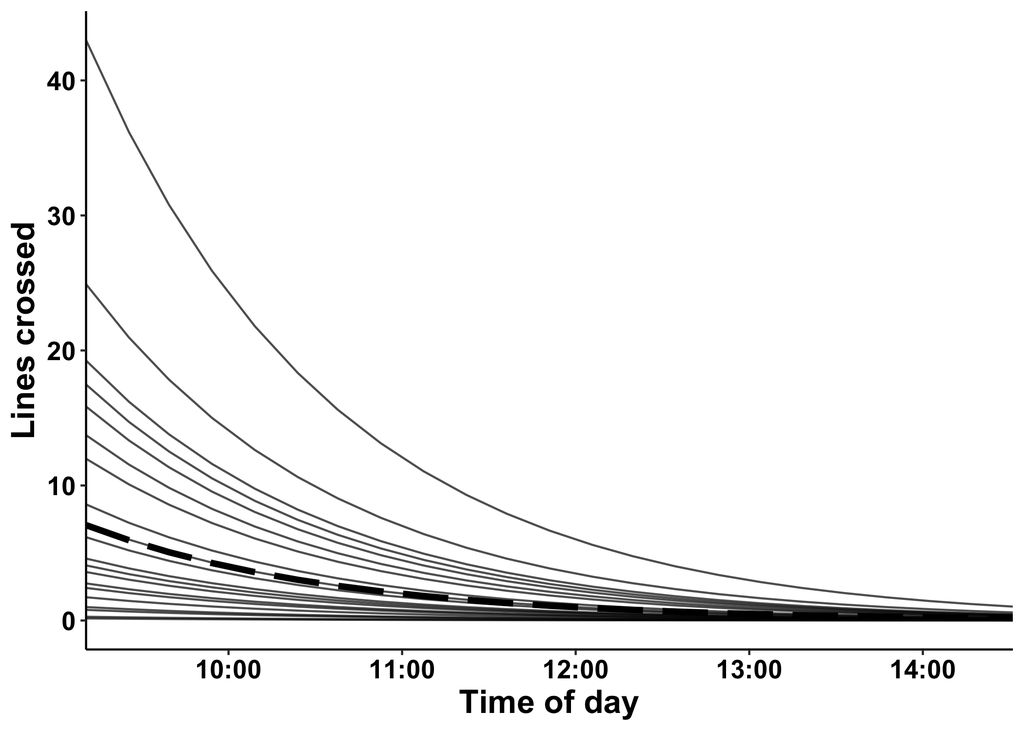

```r
# Create data set without NA values
data_act_na <-
  remove_dat_na(data_act, c("line_cross", "t_point", "t_point_sc", "trial", "mass_sc",
                             "sex", "ID", "trial_series", "day", "obsID",
                             "backg", "loc", "shel_dur"))

# Build model
m_act_plot <-
  glmmTMB(line_cross ~ t_point_sc + trial + mass_sc + backg +
            sex * loc +
            (1|ID) + (t_point_sc|trial_series),
          data = data_act_na,
          ziformula= ~ 1,
          family="nbinom2",
          contrasts = list(trial = c(-1,1), sex = c(-1,1),
                           loc = c(-1,1), backg = c(-1,1)))

# Extract predicted values for population level
dat_act_pred_pop <- as_tibble(ggeffect(m_act_plot, terms = c("t_point_sc [all]"),
                                       type = "fe"))
# Extract predicted values for individual level
dat_act_pred_ind <- as_tibble(ggpredict(m_act_plot, terms = c("t_point_sc [all]", "ID [all]"),
                                        type = "re"))

# Figure out time breaks/labels for x axis

dat_time_lab <-
  data_act_na %>%
    select(t_point) %>%
    mutate(t_point_sc = scale(t_point)) %>%
    filter(t_point %in% c(4, 8, 12, 16, 20)) %>%
    arrange(t_point) %>%
    distinct(.)

t_point_breaks <- dat_time_lab$t_point_sc  # x axis breaks
t_point_labs <- c("10:00", "11:00", "12:00", "13:00", "14:00")  # x axis labels
line_breaks <- seq(from = 0,
                   to = round(max(dat_act_pred_ind$predicted),  # y axis breaks
                                        digits = -1),
                   by = round(max(dat_act_pred_ind$predicted),
                              digits = -1)/4)

# Plot

p <- ggplot(data = dat_act_pred_pop, # pop level data
            aes(x = x,
                y = predicted)) +
  geom_line(data = dat_act_pred_ind, # ind level data
             aes(y = predicted,
                 x = x,
                 group = group),
                 alpha = 0.70) +
  geom_line(size = 1.5,  # pop mean line
            lty = "longdash") +
  scale_y_continuous(breaks = line_breaks) +
  scale_x_continuous(labels = t_point_labs,
                     breaks = t_point_breaks,
                     expand = c(0,0)) +  # moves lines to touch y-axis (no white space)
  xlab("Time of day") +
  ylab("Lines crossed") +
  #ggtitle("Lines crossed") +
  theme_bw() +
  theme(panel.grid.major = element_blank(),
        panel.grid.minor = element_blank(),
        axis.title.x = element_text(face = "bold"),
        axis.title.y = element_text(face = "bold"),
        panel.border = element_blank(),
        axis.line = element_line(),
        axis.text = element_text(face = "bold", color = "black"),
        text = element_text(size = 16))

print(p)
```

## Figure 3: Open-Field location preference during the day, by background color

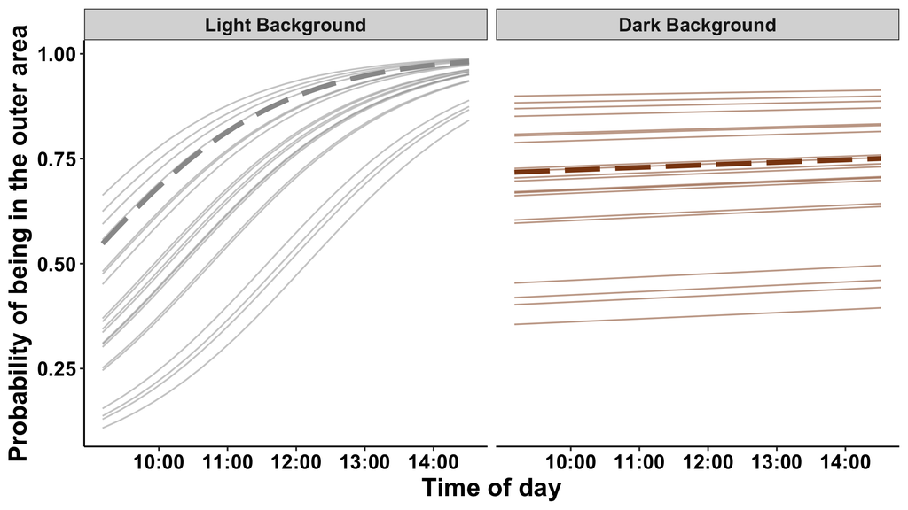

```r
# Remove NA values
data_OF <-
  remove_dat_na(data_time, c("of_loc", "t_point_sc", "trial", "mass_sc",
                             "sex", "ID", "trial_series", "day", "bkgrd",
                             "obsID"))

# Fit model
m_OF_plot <-
  glmer(of_loc ~ trial + mass_sc +
          bkgrd * t_point_sc +
          sex * bkgrd +
          (1|ID) + (t_point_sc|trial_series),
        data = data_OF,
        family = "binomial",
        contrasts = list(trial = c(-1,1), sex = c(-1,1), bkgrd = c(-1,1)),
        glmerControl(optimizer="bobyqa",
                    optCtrl = list(maxfun = 1e6)))

# Extract predicted values for population level
dat_act_pred_pop1 <-
  ggeffect(m_OF_plot, terms = c("t_point_sc [all]", "bkgrd"),
           type = "fe") %>%
  as_tibble(.) %>%
  rename(facet = group) %>%
  mutate(group = 1)

dat_act_pred_pop2 <-
  ggeffect(m_OF_plot, terms = c("t_point_sc [all]", "bkgrd"),
           type = "fe") %>%
  as_tibble(.) %>%
  rename(facet = group) %>%
  mutate(group = 2)

# combine into one so you can facet with one slope per facet
dat_act_pred_pop <-
  rbind(dat_act_pred_pop1, dat_act_pred_pop2) %>%
  mutate(group = as_factor(group),
         facet = as_factor(ifelse(facet == "Light", "Light Background",
                                                    "Dark Background")))

# Extract predicted values for individual level
dat_of_pred_ind <-
  ggpredict(m_OF_plot,
            terms = c("t_point_sc [all]", "ID [all]", "bkgrd"),
            type = "re") %>%
  as_tibble(.) %>%
  mutate(group = as.factor(group),
         facet = as_factor(ifelse(facet == "Light", "Light Background",
                                                    "Dark Background")))

## Figure out time breaks/labels for x axis

dat_time_lab <-
  data_act_na %>%
    select(t_point) %>%
    mutate(t_point_sc = scale(t_point)) %>%
    filter(t_point %in% c(4, 8, 12, 16, 20)) %>%
    arrange(t_point) %>%
    distinct(.)

t_point_breaks <- dat_time_lab$t_point_sc  # x axis breaks
t_point_labs <- c("10:00", "11:00", "12:00", "13:00", "14:00")  # x axis labels

# Plot

p <-
  ggplot(data = dat_of_pred_ind, # pop mean
         aes(x = x,
             y = predicted,
           color = facet)) +
  geom_line(aes(group = group), # ind id
            alpha = 0.50) +
  geom_line(data = dat_act_pred_pop,
              size = 1.5,
           aes(color = facet),
           lty = "longdash") +  # pop mean
  scale_x_continuous(labels = t_point_labs,
                     breaks = t_point_breaks) +
  xlab("Time of day") +
  ylab("Probability of being in the outer area") +
  scale_color_manual(name = "Background \ncolor",
                     values = c("grey60", "chocolate4")) + # color for legend
  theme_bw() +
  theme(panel.grid.major = element_blank(),
        panel.grid.minor = element_blank(),
        axis.title.x = element_text(face = "bold"),
        axis.title.y = element_text(face = "bold"),
        panel.border = element_blank(),
        axis.line = element_line(),
        axis.text = element_text(face = "bold", color = "black"),
        text = element_text(size = 16),
        strip.text.x = element_text(size=12, face="bold"),
        legend.position = "none") +
  facet_wrap(~ facet)

print(p)
```

## Figure 4: Open-Field location preference, background color and sex interaction

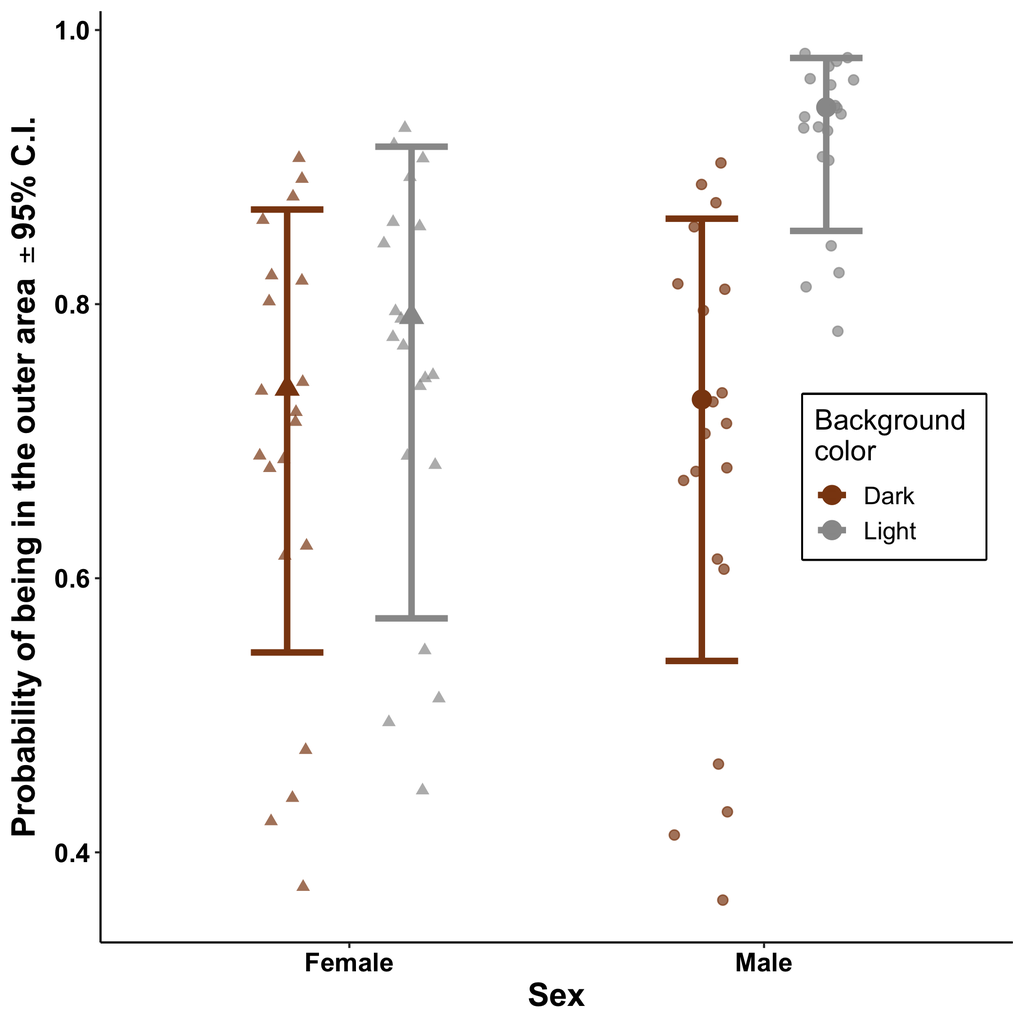

```r
# Remove NA values
data_OF <-
  remove_dat_na(data_time, c("of_loc", "t_point_sc", "trial", "mass_sc",
                             "sex", "ID", "trial_series", "day", "bkgrd",
                             "obsID"))

# Fit model
m_OF_plot <-
  glmer(of_loc ~ trial + mass_sc +
          bkgrd * t_point_sc +
          sex * bkgrd +
          (1|ID) + (t_point_sc|trial_series),
        data = data_OF,
        family = "binomial",
        contrasts = list(trial = c(-1,1), sex = c(-1,1), bkgrd = c(-1,1)),
        glmerControl(optimizer="bobyqa",
                    optCtrl = list(maxfun = 1e6)))

# Extract predicted values for population level
dat_of_pred_pop <-
  ggeffect(m_OF_plot,
           terms = c("sex", "bkgrd"),
           type = "fe")

# Get fixed effect slopes
dat_of_pred_ind <-
  ggpredict(m_OF_plot,
            terms = c("sex", "bkgrd", "ID [all]"),
            type = "re")

p <- ggplot(data = dat_of_pred_pop,
       aes(x = x,
           y = predicted,
           color = group,
           shape = x)) +
  geom_point(position = position_dodge(width = 0.6),
             size = 4) +
  geom_point(data = dat_of_pred_ind,
             aes(x = x,
                 y = predicted,
                 color = group,
                 shape = x),
             position = position_jitterdodge(dodge.width = -0.6),
             size = 2,
             alpha = 0.7) +
  geom_errorbar(aes(ymax = conf.high,
                    ymin = conf.low),
                width = 0.35,
                position = position_dodge(width = 0.6),
             size = 1.5) +
  xlab("Sex") +
  #ylab("Probability of being in the outer area of the open field") +
  ylab(expression(paste(bold(Probability~of~being~"in"~the~outer~area)~bold(""%+-%"")*bold("95"*"%"~C.I.)))) +
  scale_color_manual(name = "Background \ncolor",
                     values = c("chocolate4", "grey60")) + # color for legend
  scale_shape_manual(values = c(17, 19),
                     guide = F) + # shapes for sexess
  theme_bw() +
  theme(panel.grid.major = element_blank(),
        panel.grid.minor = element_blank(),
        axis.title.x = element_text(face = "bold"),
        axis.title.y = element_text(face = "bold"),
        panel.border = element_blank(),
        axis.line = element_line(),
        axis.text = element_text(face = "bold", color = "black"),
        text = element_text(size = 16),
        legend.position=c(0.87,0.5),
        legend.title = element_text(size = 14),
        legend.text = element_text(size = 12),
        legend.box.background = element_rect(colour = "black",
                                             size = 1))

print(p)
```